# EIPAAB_data_summary

Jake Martin

03 March 2025

# 1 ⚙️ Knit settings

Here we define our Knit settings, to make the output more user friendly, and to cache output for faster knitting.

# 2 📕 READ ME

It is designed to act as a starting point for anyone who wishes to use the ‘Evidence of the Impacts of Pharmaceuticals on Aquatic Animal Behaviour’ (EIPAAB) database for their own projects. But also as a description of how the summary present in the Manuscript was conducted.

I recommended you read the ‘README’ files before you work with the EIPAAB database, there are two ‘“’README.md’ and ‘README.csv’, start with the ‘.md’ file (https://github.com/JakeMartinResearch/EIPAAB-database/blob/main/README.md)

**P.s** Apologies for any spelling mistakes in the script I (Jake Martin) am dyslexic and this is a very long document

# 3 📑 Sharing/accessing and citing

1. **Licenses/restrictions placed on the data:** CC-BY 4.0
2. **Links to publications that cite or use the data:** Martin, JM, Michelangeli, M, Bertram, MG, Blanchfield, PJ, Brand, JA, Brodin, T, Brooks, B, Cerveny, D, Fergusson, KN, Lagisz, M, Lovin, LM, Ligocki, IY, Nakagawa, S, Ozeki, S, Sandoval-Herrera, N, Kendall, S, Sundin, J, Tan, H, Thor´e, E, Wong, BBM, McCallum, ES, (2024) Evidence of the Impacts of Pharmaceuticals on aquatic animal behaviour (EIPAAB): a systematic map and open access database. EcoEvoRxiv https://doi.org/10.32942/X2NG9R
3. **Recommended citation for this dataset:** Martin, JM, Michelangeli, M, Bertram, MG, Blanchfield, PJ, Brand, JA, Brodin, T, Brooks, B, Cerveny, D, Fergusson, KN, Lagisz, M, Lovin, LM, Ligocki, IY, Nakagawa, S, Ozeki, S, Sandoval-Herrera, N, Kendall, S, Sundin, J, Tan, H, Thor´e, E, Wong, BBM, McCallum, ES, (2024) EIPAAB database, https://doi.org/10.17605/OSF.IO/ATWY6

# 4 📧 Contact

**Jake M. Martin**

📧 **Email:** jake.martin@deakin.edu.au

📧 **Alt Email:** jake.martin.research@gmail.com

🌐 **Web:** [jakemartin.org](https://jakemartin.org/)

🐙 **GitHub**: JakeMartinResearch

# 5 ⌨️ R informartion

If you are not familiar with R, [here’s a beginners guide 📹](https://www.youtube.com/watch?v=_V8eKsto3Ug)

Here’s a link to download [R 📥](https://cran.r-project.org/) and download [R studio 📥](https://posit.co/products/open-source/rstudio/)

This is an R markdown file, which makes annotating and running R code more user friendly, it is also easy to reproducible and share in a variate of formates (e.g. htlm). The R code is embed within chunks, and the output for code will be embedded under the chuck.

```r
# This is a chuck
```

All other text outside of the chucks are annotations (like this). Hashtags used outside of chucks are used to create headers and to structure the file. Hashtags within the chucks are used for more precise annotation within the code.

If you are not familiar with R markdown, [here’s a guide](https://www.youtube.com/watch?v=tKUufzpoHDE)

# 6 📦 Required packages

These are the R packages required to run the script. I have added them to a list so that I can install them all in one go using the function below called loaded_packages. This function I have made will load all the packages in the list below, if the packages are not already installed, this function will first install them.

If you want to install and load each package separately, you can use the code install.packages() and require(), I have given a example below. To run this code you will need to install pacman first `install.packages("pacman")`

```r
# install.packages('pacman')
pacman::p_load(tidyverse, ggraph, igraph, ggrepel, RColorBrewer, ggtree, treeio,
    ape, gridExtra, ggdist, highcharter, pander, here, gt, readxl)
```

For `ggtree` and `treeio` you may need to run this code for instillation

```r
# if (!requireNamespace('BiocManager', quietly = TRUE))
# install.packages('BiocManager') BiocManager::install('ggtree')
```

# 7 📂 Directories

Creating out input and output directories. They will be made within the current parent directory (i.e. where the R sciprt is saved)

## 7.1 Output directory 📤

This is code creates a folder and saves the directory as figure_path. This is where we will export our figures

```r
figures_path <- here("figures")

if (!dir.exists(figures_path)) {
    dir.create(figures_path)
}
```

This is code creates a folder and saves the directory as output_path This is where we will export our data

```r
output_path <- here("output-data")

if (!dir.exists(output_path)) {
    dir.create(output_path)
}
```

## 7.2 Input directory 📥

```r
input_path <- here("input-data")

if (!dir.exists(figures_path)) {
    dir.create(figures_path)
}
```

# 8 📖 Database informartion

The **💿 READ-ME.csv** file which explains what each metadata is, how it was extracted, what structure it has, and at what level it applies, is available at on GitHub (https://github.com/JakeMartinResearch/EIPAAB-database/tree/main/input-data) or on the OSF (10.17605/OSF.IO/ATWY6) Below I have imported the read me for accessibility. I highly recommend you read the READ-ME before conducting any of your own meta-analysis to make sure you have interoperated the data correctly.

More generally, column names that start with ‘validity’ are metadata relating to study validity, those that start with ‘specie’s relate to species information (population), those that start with ’compound’ relate to the chemical information (exposure), those that start with ‘behav’ relate to behaviour information (outcome). The order of columns reflects both the level the metadata is extracted at (i.e. article level or species by compound level; see level in READ-ME), as well as the general category of metadata (i.e. validity, species, compound, behaviour).

```r
setwd(input_path)

READ_ME <- read.csv("READ-ME.csv", na = "NA")  # loading the READ-ME file

READ_ME %>%
    head() %>%
    gt()
```

| column_name | type | structure | level | description | validity_assessment | CRED_criteria |
| --- | --- | --- | --- | --- | --- | --- |
| article_id | string | free | article | A unique article id assigned during title and abstract screening | 0 | NA |
| response_id | string | free | article | A unique response id generated by the survey used to extract the article | 0 | NA |
| doi | string | free | article | The DOI of the article | 0 | NA |
| title | string | free | article | The title of the atricle | 0 | NA |
| year | interger | free | article | The year the article was publish | 0 | NA |
| journal | string | free | article | The name of the journal in which the article was published | 0 | NA |

# 9 💿 Importing EIPAAB database

Importing the **💿 EIPAAB-database.csv** database

It can be assessed from…

GitHub (https://github.com/JakeMartinResearch/EIPAAB-database/tree/main/input-data)

OSF (https://osf.io/atwy6/)

My personal webpage (https://jakemartin.org/eipaab-database/)

If the CSV files are in the same working directory (wd) as this R script, you will not need to use setwd(), but if the files are located elsewhere you will need to specify this in setwd(), and run all lines at once. In R markdown the working directory changes back to default after the chuck is run.

```r
setwd(input_path)

EIPAAB_database <- read.csv("EIPAAB-database.csv", na = "NA")
```

# 10 🕵️ EIPAAB summary

## 10.1 Total numbers

The first thing we will look at is how many unique (distinct) articles there are in the database, and how many rows of data there are.

There are 901 articles

```r
EIPAAB_database %>%
  dplyr::distinct(article_id) %>% # Returns a list of distinct article_id
  nrow(.) # Returns the length of the current file (which is the list of distinct article_id)
```

```
## [1] 901
```

There are 1739 rows of data

```r
EIPAAB_database %>%
    nrow(.)  # Returns the length of the current file (which is the length of the whole datafile)
```

```
## [1] 1739
```

Each row represent a unique species by compound combination within a given article. This is represented by the column unique_row_id This is a combination of the extractors response id, specie,s and compound. For example, R_0Bqz2RQ4JxPfBkZ_Danio_rerio_Diazepam, response id = R_0Bqz2RQ4JxPfBkZ, species = Danio rerio, and compound = Diazepam

```r
EIPAAB_database %>%
  dplyr::select(unique_row_id) %>% # selects just the unique_column_id column
  dplyr::arrange(unique_row_id) %>% # arranges the column alphabetically so the same examples will be given everytime
  dplyr::slice(1:10) %>% # Returns only the first 10 rows
  gt()
```

| unique_row_id |
| --- |
| R_0Bqz2RQ4JxPfBkZ_Danio_rerio_Diazepam |
| R_0CHlDBs9ipt4suZ_Astyanax_mexicanus_Aripiprazole |
| R_0Ck0AOjLDWukBUt_Procambarus_clarkii_Chlordiazepoxide |
| R_0JvaI9dlvTbozUl_Daphnia_magna_Fluoxetine |
| R_0JvaI9dlvTbozUl_Daphnia_magna_Sertraline |
| R_0Srt7zn9MwHKne1_Danio_rerio_Escitalopram |
| R_0p8ZEROmCGlSR7r_Oryzias_latipes_Fluoxetine |
| R_10C0XxjAUoZmibO_Amphiprion_ocellaris_17-alpha-ethinylestradiol |
| R_10GdzsXlrkwamUt_Daphnia_magna_Cisplatin |
| R_10NOT0XWL5TXN5m_Coenagrion_hastulatum_Diphenhydramine |

Now the number of total treatments represented in the data, this is the total number of unique doses per species by compound combination.

```r
EIPAAB_database %>%
  dplyr::summarise(
    groups = sum(compound_treatment_levels, na.rm = TRUE), # Calculate the sum of 'compound_treatment_levels' while ignoring NA values
    nas = sum(is.na(compound_treatment_levels)), # Count the number of NA values in 'compound_treatment_levels'
    total = groups + (nas * 2) # Calculate the total by adding 'groups' to twice the number of NAs
  ) %>%
  gt()
```

| groups | nas | total |
| --- | --- | --- |
| 6152 | 226 | 6604 |

## 10.2 Study motivation

Let’s look at how the evidence collected breaks down by the three study motivations

```r
total_atricles <- EIPAAB_database %>%
  dplyr::distinct(article_id) %>%
  nrow()

# Analyze the study motivations in the dataset
EIPAAB_database %>%
  dplyr::group_by(article_id) %>% # Group the data by 'article_id'
  dplyr::sample_n(1) %>% # Randomly sample one row from each group (i.e., each unique 'article_id')
  dplyr::ungroup() %>% # Ungroup the data to remove the previous grouping
  dplyr::group_by(study_motivation) %>% # Group the data by 'study_motivation'
  dplyr::reframe( # Create a summary data frame with the count and percentage of each study motivation
    n = length(study_motivation),  # Count the number of occurrences of each study motivation
    `%` = round(n / total_atricles, 3) * 100  # Calculate the percentage of total articles
  ) %>%
  dplyr::arrange(desc(n)) %>%  # Arrange the resulting data frame in descending order of the count
  gt()
```

| study_motivation | n | % |
| --- | --- | --- |
| Environmental | 510 | 56.6 |
| Medical | 233 | 25.9 |
| Basic research | 158 | 17.5 |

Here we are changing the order of these in the database to “Environmental”, “Medical”, “Basic research” for plots.

```r
EIPAAB_database <- EIPAAB_database %>%
    dplyr::mutate(study_motivation = fct_relevel(study_motivation, "Environmental",
        "Medical", "Basic research"))
```

## 10.3 Publications by year

### 10.3.1 Number per year

Year range is 1974 to 2022, so 48 years worth of empirical research has contributed to this evidence base.

```r
EIPAAB_database %>%
    dplyr::reframe(min_year = min(year), max_year = max(year), total_years = max_year -
        min_year) %>%
    gt()
```

| min_year | max_year | total_years |
| --- | --- | --- |
| 1974 | 2022 | 48 |

Now making a summary for the number of publications per year based on study motivation

```r
# Create a complete sequence of years and all unique study motivations
all_years <- as.character(1974:2022)
all_study_motivations <- unique(EIPAAB_database$study_motivation)

# Create a data frame with all combinations of year and study motivation
all_combinations <- expand.grid(year = all_years, study_motivation = all_study_motivations,
    stringsAsFactors = FALSE)

# Summarize the data
pub_year <- EIPAAB_database %>%
    group_by(year, study_motivation) %>%
    summarize(n = length(unique(article_id)), .groups = "drop") %>%
    mutate(year = as.character(year))

# Join with the complete grid of years and study motivations
pub_year_complete <- all_combinations %>%
    left_join(pub_year, by = c("year", "study_motivation")) %>%
    mutate(n = if_else(is.na(n), 0, n), year = as.numeric(year))
```

#### 10.3.1.1 Fig 2a

Here’s a summary figure for the manuscript (MS).

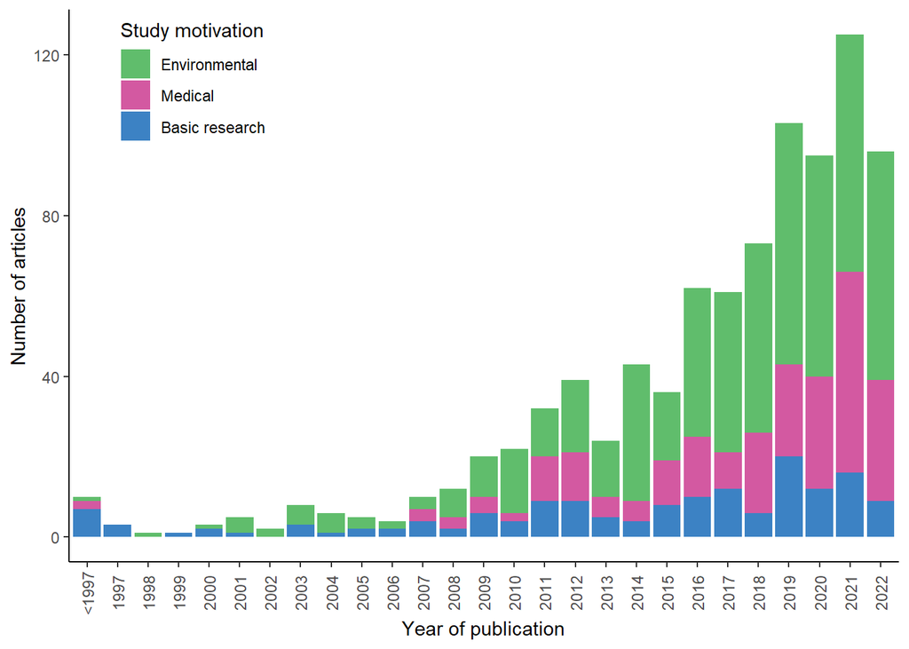

```r
# Define the colour palette
motivation_colour_theme <- c("#60BD6C", "#D359A1", "#3C82C4") # Making colour theme to apply to plot

# Create the plot
pub_year_fig <- pub_year_complete %>%
  # Group years before 1996 and reformat the year column
  dplyr::mutate(
    year = as.character(if_else(year < 1996, 1996, year)), # Grouping years before 1996
    year = if_else(year == "1996", "<1997", year)          # Renaming 1995 group to "<1996"
  ) %>%
  # Creating the plot
  ggplot(aes(y = n, x = year, fill = study_motivation)) +
  geom_bar(stat = "identity", width = 0.9) +
  # Apply the custom colours
  scale_fill_manual(values = motivation_colour_theme, name = "Study motivation") +
  theme_classic() +
  # Customizing the theme
  theme(
    legend.position = c(0.05, 1), # Positioning the legend in the top-left corner within the plot
    legend.justification = c(0, 1), # Ensuring the legend box aligns properly at the top-left corner
    axis.text.x = element_text(angle = 90, vjust = 0.5) # Rotating x-axis labels for better readability
  ) +
  # Adding axis labels
  labs(
    x = "Year of publication",
    y = "Number of articles"
  )

# Display the plot
pub_year_fig
```

Saving the figure as a PDF. I have hased this so I don’t re-write this file each time.

```r
# setwd(figures_path) ggsave('pub_year_fig.png', plot = pub_year_fig, width =
# 10, height = 5, dpi = 300) #if you want to save a png
# ggsave('study_pub_year_fig.pdf', plot = pub_year_fig, width = 10, height = 5)
```

### 10.3.2 Cumulative and relative growth

Making values for cumulative and relative growth in articles. This is the cumulative number of articles per year for each study moitvation, as well as the relative growth based on 2007. We selected 2007 for a 15 year overview in growth.

```r
pub_year_growth <- pub_year_complete %>%
  dplyr::group_by(study_motivation) %>%
  dplyr::mutate(
    n_cumulative = cumsum(n),  # Calculate the cumulative sum of 'n'
    n_cumulative_prop = n_cumulative / max(n_cumulative), # Calculate the cumulative proportion
    n_2007 = ifelse(year == 2007, n, NA_real_), # Get n value for year 2007
    n_2007 = first(na.omit(n_2007)), # Propagate the n_2012 value within the group
    n_ratio_to_2007 = n / n_2007 # Calculate number of articles relative to that of 2007
  ) %>%
  dplyr::ungroup() %>%
  dplyr::select(study_motivation, year, n, n_cumulative, n_cumulative_prop, n_ratio_to_2007)
```

Making a plot for each motivation cumulative growth since 1974 (the first identified study)

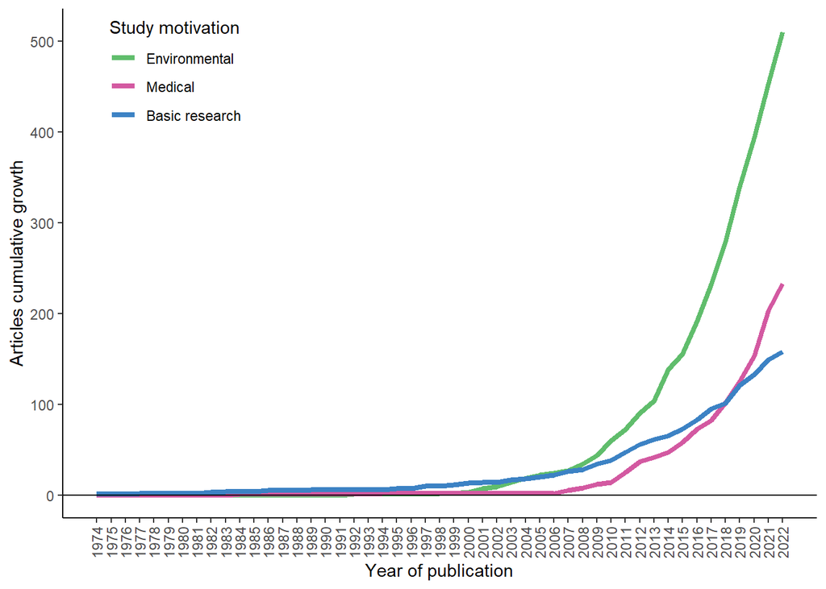

```r
cumulative_articles_fig <- pub_year_growth %>%
  ggplot(aes(y = n_cumulative, x = year, colour = study_motivation)) +
  geom_line(stat = "identity", linewidth = 1.5) +
  geom_hline(yintercept = 0) +
  scale_x_continuous(breaks = seq(1974, 2022, by = 1)) +
  scale_colour_manual(values = motivation_colour_theme, name = "Study motivation") +
  theme_classic() +
  # Customizing the theme
  theme(
    legend.position = c(0.05, 1), # Positioning the legend in the top-left corner within the plot
    legend.justification = c(0, 1), # Ensuring the legend box aligns properly at the top-left corner
    axis.text.x = element_text(angle = 90, vjust = 0.5) # Rotating x-axis labels for better readability
  ) +
  # Adding axis labels
  labs(
    x = "Year of publication",
    y = "Articles cumulative growth"
  )

cumulative_articles_fig
```

Saving this plot

```r
# setwd(figures_path) ggsave('study_cumulative_articles_fig.pdf', plot =
# cumulative_articles_fig, width = 10, height = 5)
```

## 10.4 Reltive growth

Let’s look at relative growth compared to the research area more broadly

I will identify the most common research area based on each study motivation.

Environmental motivation = Environmental Sciences & Ecology  
Medical motivation = Neurosciences & Neurology  
Basic research = Neurosciences & Neurology

```r
EIPAAB_database %>%
    dplyr::group_by(article_id) %>%
    dplyr::sample_n(1) %>%
    dplyr::ungroup() %>%
    dplyr::group_by(study_motivation, wos_research_areas) %>%
    dplyr::reframe(n = length(doi)) %>%
    dplyr::mutate(wos_research_areas = str_trim(wos_research_areas)) %>%
    tidyr::separate_rows(wos_research_areas, sep = ";") %>%
    dplyr::mutate(wos_research_areas = str_trim(wos_research_areas)) %>%
    dplyr::group_by(study_motivation, wos_research_areas) %>%
    dplyr::reframe(n_total = sum(n)) %>%
    dplyr::arrange(desc(n_total)) %>%
    dplyr::arrange(study_motivation) %>%
    dplyr::group_by(study_motivation) %>%
    dplyr::slice(1:2) %>%
    dplyr::ungroup() %>%
    gt()
```

| study_motivation | wos_research_areas | n_total |
| --- | --- | --- |
| Environmental | Environmental Sciences & Ecology | 321 |
| Environmental | Toxicology | 193 |
| Medical | Neurosciences & Neurology | 106 |
| Medical | Pharmacology & Pharmacy | 72 |
| Basic research | Neurosciences & Neurology | 56 |
| Basic research | Behavioral Sciences | 43 |

We will now compare the proportion cumulative growth of each study motivation against the most common research areas based on WoS.

I have searched articles published within these research areas from 1992-2022, and create a database to compare against.

Each search indued only a date range (e.g. PY=(1992-2021)) AND the given web of science resarch area (e.g. WC=(Pharmacology & Pharmacy)). Searchers were done on the 04/07/2024. Only the total number of articles each year was taken.

```r
setwd(input_path)

wos_research_areas_n <- read_excel("martin-et-al-additional-file-10-wos-research-areas-1992-2022.xlsx", sheet = "sheet1") %>%
  dplyr::arrange(year) %>%
  dplyr::group_by(research_area) %>%
  dplyr::mutate(
    n_cumulative = cumsum(n),  # Calculate the cumulative sum of 'n'
    n_cumulative_prop = n_cumulative / max(n_cumulative), # Calculate the cumulative proportion
    n_2007 = ifelse(year == 2007, n, NA_real_), # Get n value for year 2011
    n_2007= first(na.omit(n_2007)), # Propagate the n_2011 value within the group
    n_ratio_to_2007 = n / n_2007 # Calculate n_ratio_to_2000
  ) %>%
  dplyr::ungroup() %>%
  dplyr::select(research_area, year, n, n_cumulative, n_cumulative_prop, n_ratio_to_2007)
```

Combined the number of articles with those in the EIPAAB database

```r
pub_year_growth_comp <- pub_year_growth %>%
    dplyr::rename(research_area = study_motivation)

wos_research_areas_comp <- wos_research_areas_n %>%
    rbind(., pub_year_growth_comp) %>%
    dplyr::mutate(research_area = factor(research_area, levels = c("Environmental",
        "Medical", "Basic research", "Environmental Sciences and Ecology", "Toxicology",
        "Neurosciences and Neurology", "Pharmacology and Pharmacy", "All Research Areas")))
```

Let’s see what the relative growth was in 2022 (the latest included year in the evidence base)

```r
wos_research_areas_comp %>%
    dplyr::filter(year == 2022) %>%
    gt()
```

| research_area | year | n | n_cumulative | n_cumulative_prop | n_ratio_to_2007 |
| --- | --- | --- | --- | --- | --- |
| Pharmacology and Pharmacy | 2022 | 80433 | 1458833 | 1 | 1.765779 |
| Neurosciences and Neurology | 2022 | 24448 | 450515 | 1 | 1.604094 |
| Toxicology | 2022 | 16913 | 391858 | 1 | 1.409299 |
| Environmental Sciences and Ecology | 2022 | 4599 | 103123 | 1 | 1.066064 |
| All Research Areas | 2022 | 3618082 | 66839129 | 1 | 1.790462 |
| Environmental | 2022 | 57 | 510 | 1 | 19.000000 |
| Medical | 2022 | 30 | 233 | 1 | 10.000000 |
| Basic research | 2022 | 9 | 158 | 1 | 2.250000 |

### 10.4.1 Enviormental relative growth

#### 10.4.1.1 Fig 2b-1

Let’s now compare the relative growth in Environmental research

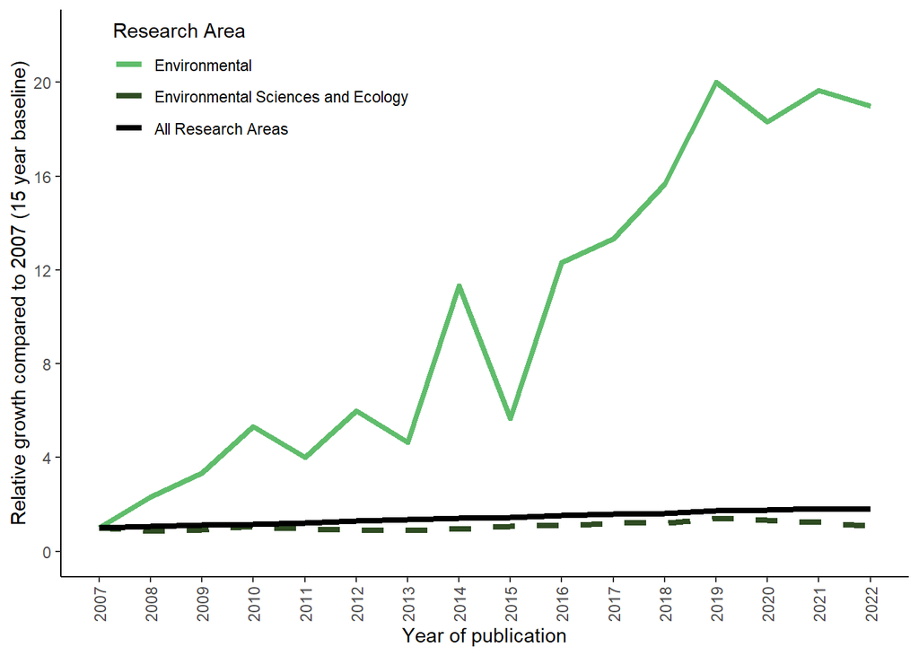

```r
# Define the colour palette
env_colour_theme <- c("#60BD6C", "#2E4B22", "black") # Making colour theme to apply to plot

enviro_comp <-  c("Environmental", "Environmental Sciences and Ecology", "All Research Areas")

line_types <- c("Environmental" = "solid",
                "Environmental Sciences and Ecology" = "dashed",
                "All Research Areas" = "solid")

relative_growth_env_fig <- wos_research_areas_comp %>%
  dplyr::filter(research_area %in% enviro_comp, year > 2006) %>%
  ggplot(aes(y = n_ratio_to_2007, x = year, colour = research_area, linetype = research_area)) +
  geom_line(stat = "identity", linewidth = 1.5) +
  scale_x_continuous(breaks = seq(2007, 2022, by = 1)) +
  scale_y_continuous(limits = c(0, 22), breaks = seq(0, 22, by = 4)) + # Scale Y axis from 0 to 22
  scale_colour_manual(values = env_colour_theme, name = "Research Area") +
  scale_linetype_manual(values = line_types) + # Apply manual line types
  guides(linetype = "none") + # Remove legend for line types
  theme_classic() +
  # Customizing the theme
  theme(
    legend.position = c(0.05, 1), # Positioning the legend in the top-left corner within the plot
    legend.justification = c(0, 1), # Ensuring the legend box aligns properly at the top-left corner
    axis.text.x = element_text(angle = 90, vjust = 0.5) # Rotating x-axis labels for better readability
  ) +
  # Adding axis labels
  labs(
    x = "Year of publication",
    y = "Relative growth compared to 2007 (15 year baseline)"
  )

relative_growth_env_fig
```

Save this figure

```r
# setwd(figures_path) ggsave('study_relative_growth_env_fig.pdf', plot =
# relative_growth_env_fig, width = 5, height = 5)
```

### 10.4.2 Medical relative growth

#### 10.4.2.1 Fig 2b-2

Comparing the relative growth in medical research

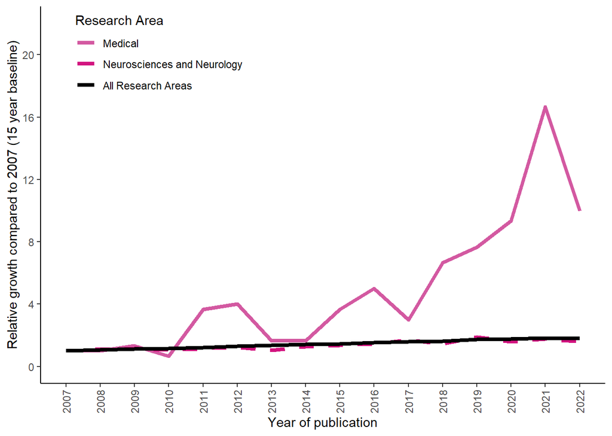

```r
# Define the colour palette
med_colour_theme <- c("#D359A1", "#D2137F", "black") # Making colour theme to apply to plot

med_comp <-  c("Medical", "Neurosciences and Neurology", "All Research Areas")

line_types <- c("Medical" = "solid",
                "Neurosciences and Neurology" = "dashed",
                "All Research Areas" = "solid")

relative_growth_med_fig <- wos_research_areas_comp %>%
  dplyr::filter(research_area %in% med_comp, year > 2006) %>%
  ggplot(aes(y = n_ratio_to_2007, x = year, colour = research_area, linetype = research_area)) +
  geom_line(stat = "identity", linewidth = 1.5) +
  scale_x_continuous(breaks = seq(2007, 2022, by = 1)) +
  scale_y_continuous(limits = c(0, 22), breaks = seq(0, 22, by = 4)) + # Scale Y axis from 0 to 22
  scale_colour_manual(values = med_colour_theme, name = "Research Area") +
  scale_linetype_manual(values = line_types) + # Apply manual line types
  guides(linetype = "none") + # Remove legend for line types
  theme_classic() +
  # Customizing the theme
  theme(
    legend.position = c(0.05, 1), # Positioning the legend in the top-left corner within the plot
    legend.justification = c(0, 1), # Ensuring the legend box aligns properly at the top-left corner
    axis.text.x = element_text(angle = 90, vjust = 0.5) # Rotating x-axis labels for better readability
  ) +
  # Adding axis labels
  labs(
    x = "Year of publication",
    y = "Relative growth compared to 2007 (15 year baseline)"
  )

relative_growth_med_fig
```

Save this figure

```r
# setwd(figures_path) ggsave('study_relative_growth_med_fig.pdf', plot =
# relative_growth_med_fig, width = 5, height = 5)
```

### 10.4.3 Basic resarch relative growth

#### 10.4.3.1 Fig 2b-3

Comparing relative growth in basic research

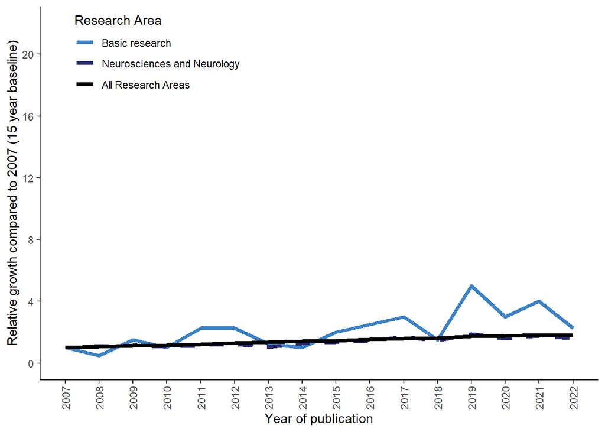

```r
# Define the colour palette
basic_colour_theme <- c("#3C82C4", "#26276D", "black") # Making colour theme to apply to plot

basic_comp <-  c("Basic research", "Neurosciences and Neurology", "All Research Areas")

line_types <- c("Basic research" = "solid",
                "Neurosciences and Neurology" = "dashed",
                "All Research Areas" = "solid")

relative_growth_base_fig <- wos_research_areas_comp %>%
  dplyr::filter(research_area %in% basic_comp, year > 2006) %>%
  ggplot(aes(y = n_ratio_to_2007, x = year, colour = research_area, linetype = research_area)) +
  geom_line(stat = "identity", linewidth = 1.5) +
  scale_x_continuous(breaks = seq(2007, 2022, by = 1)) +
  scale_y_continuous(limits = c(0, 22), breaks = seq(0, 22, by = 4)) + # Scale Y axis from 0 to 22
  scale_colour_manual(values = basic_colour_theme, name = "Research Area") +
  scale_linetype_manual(values = line_types) + # Apply manual line types
  guides(linetype = "none") + # Remove legend for line types
  theme_classic() +
  # Customizing the theme
  theme(
    legend.position = c(0.05, 1), # Positioning the legend in the top-left corner within the plot
    legend.justification = c(0, 1), # Ensuring the legend box aligns properly at the top-left corner
    axis.text.x = element_text(angle = 90, vjust = 0.5) # Rotating x-axis labels for better readability
  ) +
  # Adding axis labels
  labs(
    x = "Year of publication",
    y = "Relative growth compared to 2007 (15 year baseline)"
  )

relative_growth_base_fig
```

Save this figure

```r
# setwd(figures_path) ggsave('study_relative_growth_base_fig.pdf', plot =
# relative_growth_base_fig, width = 5, height = 5)
```

## 10.5 Population, Exposure and Outcome

Looking at the link between the PEO elements. What was the average study design.

Below I have made a table that groups by these elements to see the average study design

It was 1 compound, 1 species and 1 behavioural class (41%)

```r
behav_boolean <- c("behav_movement_boolean", "behav_boldness_boolean", "behav_foraging_boolean", "behav_antipredator_boolean", "behav_mating_boolean", "behav_post_mating_boolean", "behav_agression_boolean", "behav_sociality_boolean", "behav_cognition_boolean", "behav_noncat_boolean")

EIPAAB_database %>%
  dplyr::mutate(behav_n = rowSums(across(all_of(behav_boolean)), na.rm = TRUE)) %>% # how many behav class measured
  dplyr::group_by(article_id) %>%
  dplyr::arrange(desc(behav_n)) %>%
  dplyr::slice(1) %>%
  dplyr::ungroup() %>%
  dplyr::select(compound_n, species_n, behav_n) %>%
  dplyr::group_by(compound_n, species_n, behav_n) %>%
  dplyr::reframe(n= length(compound_n),
                 '%' = round(n/902*100,1)) %>%
  dplyr::arrange(desc(n)) %>%
  dplyr::slice(1:10) %>% # Only the 10 most common combinations
  gt()
```

| compound_n | species_n | behav_n | n | % |
| --- | --- | --- | --- | --- |
| 1 | 1 | 1 | 374 | 41.5 |
| 1 | 1 | 2 | 160 | 17.7 |
| 2 | 1 | 1 | 78 | 8.6 |
| 1 | 1 | 3 | 63 | 7.0 |
| 3 | 1 | 1 | 45 | 5.0 |
| 2 | 1 | 2 | 34 | 3.8 |
| 4 | 1 | 1 | 24 | 2.7 |
| 3 | 1 | 2 | 15 | 1.7 |
| 1 | 2 | 1 | 13 | 1.4 |
| 5 | 1 | 1 | 9 | 1.0 |

I summary df that has the number of PEO elements in each of the 901 studies

```r
PEO_element_summary <- EIPAAB_database %>%
    dplyr::mutate(behav_n = rowSums(across(all_of(behav_boolean)), na.rm = TRUE)) %>%
    dplyr::group_by(article_id) %>%
    dplyr::arrange(desc(behav_n)) %>%
    dplyr::slice(1) %>%
    dplyr::ungroup() %>%
    dplyr::select(compound_n, species_n, behav_n)
```

Looking at the number of species used

```r
PEO_element_summary %>%
    dplyr::group_by(species_n) %>%
    dplyr::reframe(n = length(species_n), `%` = n/901) %>%
    gt()
```

| species_n | n | % |
| --- | --- | --- |
| 1 | 873 | 0.968923418 |
| 2 | 25 | 0.027746948 |
| 3 | 1 | 0.001109878 |
| 4 | 1 | 0.001109878 |
| 5 | 1 | 0.001109878 |

Looking at the number of compounds used

```r
PEO_element_summary %>%
    dplyr::group_by(compound_n) %>%
    dplyr::reframe(n = length(compound_n), `%` = n/901) %>%
    dplyr::slice(1:10) %>%
    gt()
```

| compound_n | n | % |
| --- | --- | --- |
| 1 | 624 | 0.692563818 |
| 2 | 127 | 0.140954495 |
| 3 | 67 | 0.074361820 |
| 4 | 32 | 0.035516093 |
| 5 | 16 | 0.017758047 |
| 6 | 8 | 0.008879023 |
| 7 | 6 | 0.006659267 |
| 8 | 5 | 0.005549390 |
| 9 | 1 | 0.001109878 |
| 10 | 2 | 0.002219756 |

The number of different behaviours

```r
PEO_element_summary %>%
    dplyr::group_by(behav_n) %>%
    dplyr::reframe(n = length(species_n), `%` = n/901) %>%
    gt()
```

| behav_n | n | % |
| --- | --- | --- |
| 1 | 583 | 0.647058824 |
| 2 | 227 | 0.251942286 |
| 3 | 78 | 0.086570477 |
| 4 | 10 | 0.011098779 |
| 5 | 2 | 0.002219756 |
| 7 | 1 | 0.001109878 |

## 10.6 Species

Let’s take a closer look at species information

### 10.6.1 Number of distict species

There are 173 species in the EIPAAB database

```r
EIPAAB_database %>%
    dplyr::distinct(species_name) %>%
    nrow()
```

```
## [1] 173
```

The number of spp each study motivation

```r
EIPAAB_database %>%
    dplyr::group_by(study_motivation) %>%
    dplyr::reframe(n_spp = length(unique(species_name)), total_study = length(unique(article_id)),
        rel_n = n_spp/total_study) %>%
    gt()
```

| study_motivation | n_spp | total_study | rel_n |
| --- | --- | --- | --- |
| Environmental | 143 | 510 | 0.2803922 |
| Medical | 25 | 233 | 0.1072961 |
| Basic research | 43 | 158 | 0.2721519 |

There are 21 class

```r
EIPAAB_database %>%
    dplyr::distinct(species_class) %>%
    nrow()
```

```
## [1] 21
```

There are 935 different groups of animals used across all 901 studies (i.e. some studies had more then one species)

```r
EIPAAB_database %>%
    dplyr::distinct(unique_population_id) %>%
    nrow(.)
```

```
## [1] 935
```

### 10.6.2 Major taxa groups

#### 10.6.2.1 Cladogram (Taxonomic tree)

Let’s make a Cladogram to get an overview of what taxa are in the database

```r
spp_taxonomy <- EIPAAB_database %>%
    dplyr::group_by(species_name) %>%
    dplyr::sample_n(1) %>%
    dplyr::ungroup() %>%
    dplyr::filter(!is.na(species_family), !str_detect(species_species, "spp."), species_kingdom !=
        "Chromista") %>%
    dplyr::select("species_kingdom", "species_phylum", "species_class", "species_order",
        "species_family", "species_genus", "species_species") %>%
    dplyr::mutate(species_species = paste0(substr(species_genus, 1, 1), ". ", sub("^[^ ]+ ",
        "", species_species)))
# The mutate changes the spp name to abbreviate the Genus (e.g. Aeshna cyanea
# to A. cyanea)
```

Create a hierarchical structure for the plot

```r
taxonomy <- spp_taxonomy[, c("species_kingdom", "species_phylum", "species_class",
    "species_order", "species_family", "species_genus", "species_species")]

taxonomy[] <- lapply(taxonomy, factor)

# Create a phylogenetic tree
phylo_tree <- as.phylo.formula(~species_kingdom/species_phylum/species_class/species_order/species_family/species_genus/species_species,
    data = taxonomy)
```

Manual creating a phylo_tree (with equal branches)

```r
ggtree_obj <- ggtree(phylo_tree, branch.length='none', layout='circular')

# Extract the phylum information for coloring
#taxonomy$label <- paste0(substr(spp_taxonomy$species_genus, 1, 1), ". ", spp_taxonomy$species_species)
class_info <- taxonomy$species_class[match(phylo_tree$tip.label, taxonomy$species_species)]

# Add the phylum information to the ggtree object
ggtree_obj <- ggtree_obj %<+% data.frame(label = phylo_tree$tip.label, class = class_info)

# Create a color vector for the phylum levels
class_colors <- rainbow(length(unique(class_info)))
names(class_colors) <- unique(class_info)

# Plot the cladogram with colored branches
spp_cladogram <- ggtree_obj +
  geom_tiplab(size=3) + #If you want to add species names
  geom_tree(aes(color=class)) +
  scale_color_manual(values = class_colors) +
  theme(legend.position = "right")
```

#### 10.6.2.2 Fig 3a

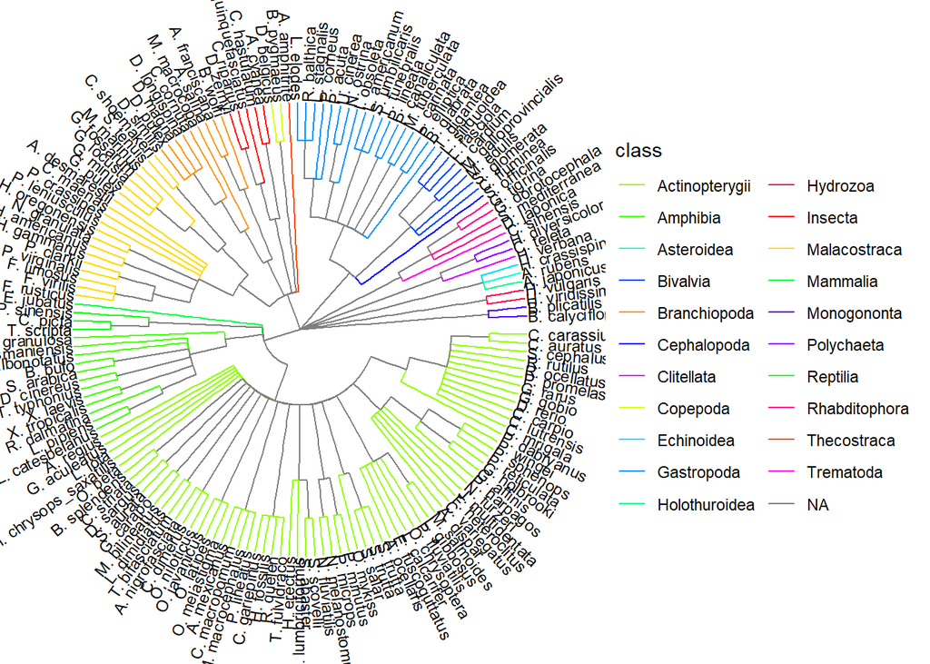

```r
spp_cladogram
```

Save the figure

```r
# setwd(figures_path) ggsave('spp_cladogram.pdf', plot = spp_cladogram, width =
# 8, height = 5)
```

#### 10.6.2.3 Class level

Let’s group by class to see the major taxonomic Classes used

First removing cases where species_species was “spp.” replacing with NA for taxonomic classification

```r
EIPAAB_database <- EIPAAB_database %>%
    dplyr::mutate(species_species = if_else(species_species == "spp.", NA, species_species))
```

Let’s look at the major Class

```r
# Total number of spp
n_spp <- EIPAAB_database %>%
    dplyr::distinct(species_name) %>%
    nrow()

# Number of spp per Class and per phylum
spp_classes <- EIPAAB_database %>%
    dplyr::group_by(species_class, species_phylum) %>%
    dplyr::reframe(count_class = length(unique(species_name)), percent_class = round(count_class/n_spp *
        100, 1)) %>%
    dplyr::group_by(species_phylum) %>%
    dplyr::mutate(count_phylum = sum(count_class), percent_phylum = round(count_phylum/n_spp *
        100, 1)) %>%
    dplyr::ungroup() %>%
    dplyr::arrange(desc(percent_class))


spp_classes %>%
    dplyr::slice(1:10) %>%
    gt()
```

| species_class | species_phylum | count_class | percent_class | count_phylum | percent_phylum |
| --- | --- | --- | --- | --- | --- |
| Actinopterygii | Chordata | 71 | 41.0 | 87 | 50.3 |
| Malacostraca | Arthropoda | 21 | 12.1 | 42 | 24.3 |
| Gastropoda | Mollusca | 19 | 11.0 | 28 | 16.2 |
| Amphibia | Chordata | 12 | 6.9 | 87 | 50.3 |
| Branchiopoda | Arthropoda | 10 | 5.8 | 42 | 24.3 |
| Bivalvia | Mollusca | 8 | 4.6 | 28 | 16.2 |
| Insecta | Arthropoda | 8 | 4.6 | 42 | 24.3 |
| Rhabditophora | Platyhelminthes | 5 | 2.9 | 6 | 3.5 |
| Reptilia | Chordata | 3 | 1.7 | 87 | 50.3 |
| Copepoda | Arthropoda | 2 | 1.2 | 42 | 24.3 |

Making a figure for the 15 most abundant Class, it terms of species diversity in the EIPAAB database

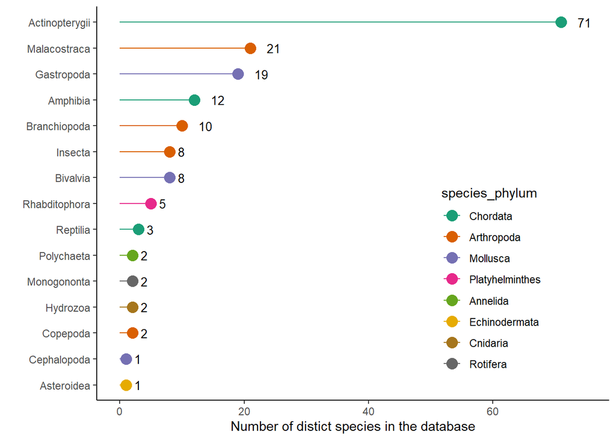

```r
class_n_spp_fig <- spp_classes %>%
  dplyr::arrange(desc(percent_class)) %>% # arrange the dataset
  dplyr::slice(1:15) %>% # Take only the most diverse 15 Class
  dplyr::mutate(species_class = fct_reorder(species_class, percent_class), # Order by diversity
                species_phylum = fct_reorder(species_phylum, desc(percent_phylum))) %>% # Order by diversity
  ggplot(aes(x=species_class, y=count_class, color = species_phylum)) +
  geom_segment(aes(x=species_class, xend=species_class, y=0, yend=count_class)) +
  geom_point(size=4) +
  geom_text(aes(label = count_class),
            hjust=-1.2,
            size=3.5,
            color="black") +
  scale_colour_brewer(palette= "Dark2") +
  coord_flip() +
  ylim(0, 75) +
  theme_classic() +
   labs(
    x = "",
    y = "Number of distict species in the database"
  ) +
   theme(legend.position = c(0., 0.05),  # Positioning the legend inside the plot
    legend.justification = c(-3, 0),   # Bottom left inside the plot
    legend.box.just = "right",
    legend.background = element_rect(fill=alpha('white', 0.5))
   )

class_n_spp_fig
```

Save the figure

```r
# setwd(figures_path) ggsave('spp_class_n_spp_fig.pdf', plot = class_n_spp_fig,
# width = 5, height = 5)
```

#### 10.6.2.4 Phylum level

Here’s a look at the % at the phylum level

```r
# In the class summary we also included percent_phylum
spp_classes %>%
    dplyr::group_by(species_phylum) %>%
    dplyr::sample_n(1) %>%
    dplyr::ungroup() %>%
    dplyr::select(-species_class, -count_class, -percent_class) %>%
    dplyr::arrange(desc(percent_phylum)) %>%
    gt()
```

| species_phylum | count_phylum | percent_phylum |
| --- | --- | --- |
| Chordata | 87 | 50.3 |
| Arthropoda | 42 | 24.3 |
| Mollusca | 28 | 16.2 |
| Platyhelminthes | 6 | 3.5 |
| Annelida | 3 | 1.7 |
| Echinodermata | 3 | 1.7 |
| Cnidaria | 2 | 1.2 |
| Rotifera | 2 | 1.2 |

A ring chart at the phylum level

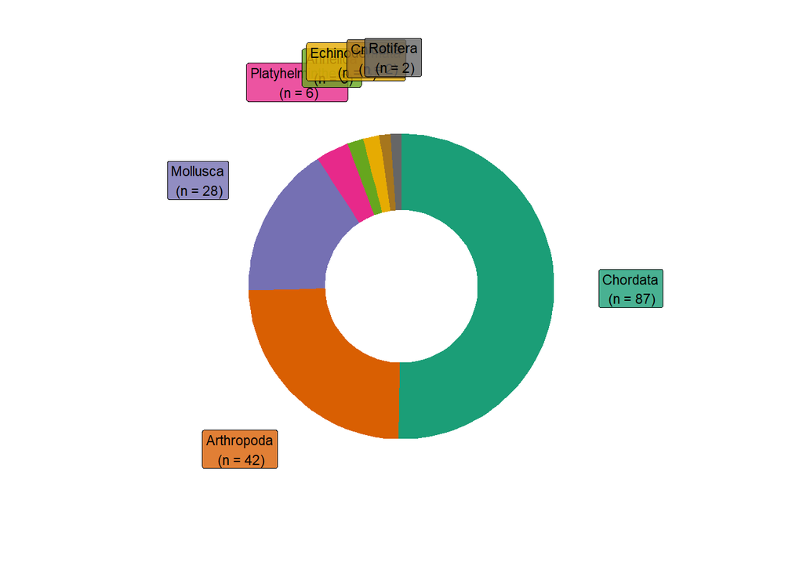

```r
ring_plot_df <- spp_classes %>%
    dplyr::slice(1:15) %>%
    dplyr::group_by(species_phylum) %>%
    dplyr::sample_n(1) %>%
    dplyr::ungroup() %>%
    dplyr::select(species_phylum, count_phylum) %>%
    dplyr::mutate(percent_phylum = count_phylum/sum(count_phylum)) %>%
    dplyr::arrange(desc(percent_phylum))

# Compute the cumulative percentages (top of each rectangle)
ring_plot_df$ymax = cumsum(ring_plot_df$percent_phylum)

# Compute the bottom of each rectangle
ring_plot_df$ymin = c(0, head(ring_plot_df$ymax, n = -1))

# Compute label position
ring_plot_df$labelPosition <- (ring_plot_df$ymax + ring_plot_df$ymin)/2

# Compute a good label
ring_plot_df$label <- paste0(ring_plot_df$species_phylum, "\n (n = ", ring_plot_df$count_phylum,
    ")")


phylum_ring_fig <- ring_plot_df %>%
    dplyr::mutate(species_phylum = fct_reorder(species_phylum, desc(percent_phylum))) %>%
    ggplot(aes(ymax = ymax, ymin = ymin, xmax = 4, xmin = 3, fill = species_phylum)) +
    geom_rect() + coord_polar(theta = "y") + geom_label(x = 5, aes(y = labelPosition,
    label = label), size = 3, alpha = 0.8) + scale_fill_brewer(palette = "Dark2") +
    xlim(c(2, 5)) + theme_void() + theme(legend.position = "none")

phylum_ring_fig
```

Save this plot

```r
# setwd(figures_path) ggsave('spp_phylum_ring_fig.pdf', plot = phylum_ring_fig,
# width = 5, height = 5)
```

### 10.6.3 Taxa representation

Now we will look at how many times each phylum, class, order, family, genus, species appear in the database

First we will make a dataset that counts the number of species within each phylum, class, order, family, and genus.

```r
# Step 1: Separate and pivot the data
lineage_data <- EIPAAB_database %>%
    pivot_longer(cols = c("species_phylum", "species_class", "species_order", "species_family",
        "species_genus", "species_species"), names_to = "lineage_level", values_to = "classification") %>%
    dplyr::mutate(lineage_level = str_remove(lineage_level, "species_"))


# Define the order
lineage_levels_order <- c("phylum", "class", "order", "family", "genus", "species")

# Step 2: Create parent-child relationships
lineage_data <- lineage_data %>%
    group_by(unique_row_id) %>%
    mutate(parent = case_when(lineage_level == "phylum" ~ "Animalia", lineage_level ==
        "class" ~ lag(classification, 1), lineage_level == "order" ~ lag(classification,
        1), lineage_level == "family" ~ lag(classification, 1), lineage_level ==
        "genus" ~ lag(classification, 1), lineage_level == "species" ~ lag(classification,
        1), )) %>%
    ungroup()
```

Here we sum the total number of species used in the database across each taxonomic classification

```r
n_rows <- EIPAAB_database %>%
    nrow()

lineage_count_use <- lineage_data %>%
    dplyr::group_by(classification, lineage_level, parent) %>%
    dplyr::reframe(classification_count = length(unique_row_id), classification_percent = round(classification_count/n_rows *
        100, 1))
```

#### 10.6.3.1 Fig 3b

Making a plot to look at the 15 most commonly used class, but you can do this at any of the taxonomic levels

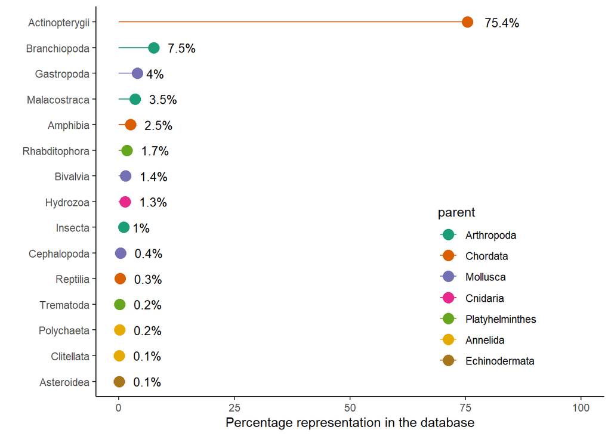

```r
class_use_fig <- lineage_count_use %>%
  dplyr::filter(lineage_level == "class") %>%
  dplyr::arrange(desc(classification_percent)) %>%
  dplyr::slice(1:15) %>%
  dplyr::mutate(classification = fct_reorder(classification, classification_percent),
                parent = fct_reorder(parent, desc(classification_percent))) %>%
  ggplot(aes(x=classification, y=classification_percent, color = parent)) +
  geom_segment(aes(x=classification, xend=classification, y=0, yend=classification_percent)) +
  geom_point(size=4) +
  geom_text(aes(label = paste0(round(classification_percent,2), "%")),
            hjust=-0.5,
            size=3.5,
            color="black") +
  scale_colour_brewer(palette= "Dark2") +
  coord_flip() +
  ylim(0, 100) +
  theme_classic() +
   labs(
    x = "",
    y = "Percentage representation in the database"
  ) +
   theme(legend.position = c(0., 0.05),  # Positioning the legend inside the plot
    legend.justification = c(-3, 0),   # Bottom left inside the plot
    legend.box.just = "right",
    legend.background = element_rect(fill=alpha('white', 0.5))
   )

class_use_fig
```

Save plot

```r
# setwd(figures_path) ggsave('spp_class_use_fig.pdf', plot = class_use_fig,
# width = 5, height = 5)
```

Table of occurrence, and percentage occurrence

```r
lineage_count_use %>%
    dplyr::filter(lineage_level == "class") %>%
    dplyr::group_by(classification) %>%
    dplyr::sample_n(1) %>%
    dplyr::ungroup() %>%
    dplyr::arrange(desc(classification_percent)) %>%
    gt()
```

| classification | lineage_level | parent | classification_count | classification_percent |
| --- | --- | --- | --- | --- |
| Actinopterygii | class | Chordata | 1311 | 75.4 |
| Branchiopoda | class | Arthropoda | 130 | 7.5 |
| Gastropoda | class | Mollusca | 69 | 4.0 |
| Malacostraca | class | Arthropoda | 61 | 3.5 |
| Amphibia | class | Chordata | 44 | 2.5 |
| Rhabditophora | class | Platyhelminthes | 29 | 1.7 |
| Bivalvia | class | Mollusca | 25 | 1.4 |
| Hydrozoa | class | Cnidaria | 22 | 1.3 |
| Insecta | class | Arthropoda | 17 | 1.0 |
| Cephalopoda | class | Mollusca | 7 | 0.4 |
| Reptilia | class | Chordata | 6 | 0.3 |
| Polychaeta | class | Annelida | 4 | 0.2 |
| Trematoda | class | Platyhelminthes | 3 | 0.2 |
| Asteroidea | class | Echinodermata | 1 | 0.1 |
| Clitellata | class | Annelida | 1 | 0.1 |
| Copepoda | class | Arthropoda | 2 | 0.1 |
| Echinoidea | class | Echinodermata | 1 | 0.1 |
| Holothuroidea | class | Echinodermata | 1 | 0.1 |
| Mammalia | class | Chordata | 2 | 0.1 |
| Monogononta | class | Rotifera | 2 | 0.1 |
| Thecostraca | class | Arthropoda | 1 | 0.1 |

Here’s break down by Phylum

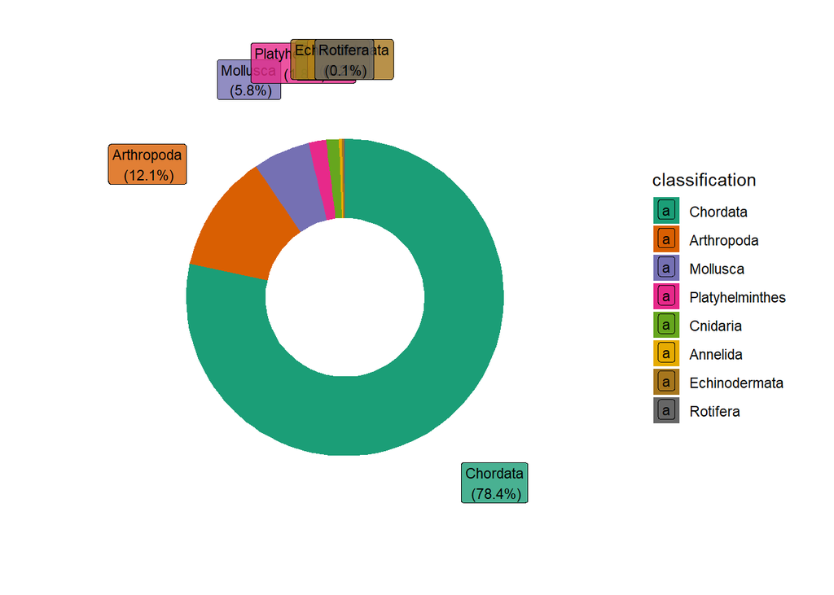

```r
ring_use_plot_df <- lineage_count_use %>%
    dplyr::filter(lineage_level == "phylum") %>%
    dplyr::arrange(desc(classification_percent)) %>%
    dplyr::mutate(classification_percent = round(classification_percent, 2)) %>%
    dplyr::slice(1:8)

# Compute the cumulative percentages (top of each rectangle)
ring_use_plot_df$ymax = cumsum(ring_use_plot_df$classification_percent)

# Compute the bottom of each rectangle
ring_use_plot_df$ymin = c(0, head(ring_use_plot_df$ymax, n = -1))

# Compute label position
ring_use_plot_df$labelPosition <- (ring_use_plot_df$ymax + ring_use_plot_df$ymin)/2

# Compute a good label
ring_use_plot_df$label <- paste0(ring_use_plot_df$classification, "\n (", ring_use_plot_df$classification_percent,
    "%)")


phylum_use_ring_fig <- ring_use_plot_df %>%
    dplyr::mutate(classification = fct_reorder(classification, desc(classification_percent))) %>%
    ggplot(aes(ymax = ymax, ymin = ymin, xmax = 4, xmin = 3, fill = classification)) +
    geom_rect() + coord_polar(theta = "y") + geom_label(x = 5, aes(y = labelPosition,
    label = label), size = 3, alpha = 0.8) + scale_fill_brewer(palette = "Dark2") +
    xlim(c(2, 5)) + theme_void()
# theme(legend.position = 'none')

phylum_use_ring_fig
```

Save the figure

```r
# setwd(figures_path) ggsave('spp_phylum_use_ring_fig.pdf', plot =
# phylum_use_ring_fig, width = 5, height = 5)
```

#### 10.6.3.2 Taxa representation by study motivation

Making a data set that looks at relative representation by each motivation, and the total

```r
lineage_count_use_motivation <- lineage_data %>%
    dplyr::group_by(study_motivation, lineage_level, parent, classification) %>%
    dplyr::reframe(classification_count = length(unique_row_id)) %>%
    dplyr::group_by(study_motivation, lineage_level) %>%
    dplyr::mutate(n_motivation = sum(classification_count)) %>%
    dplyr::ungroup() %>%
    dplyr::mutate(classification_percent = (classification_count/n_motivation) *
        100)

lineage_count_use_all <- lineage_data %>%
    dplyr::group_by(lineage_level, parent, classification) %>%
    dplyr::reframe(classification_count = length(unique_row_id)) %>%
    dplyr::group_by(lineage_level) %>%
    dplyr::mutate(n_motivation = sum(classification_count)) %>%
    dplyr::ungroup() %>%
    dplyr::mutate(classification_percent = (classification_count/n_motivation) *
        100) %>%
    dplyr::mutate(study_motivation = "All")

lineage_count_use_motivation <- lineage_count_use_motivation %>%
    rbind(., lineage_count_use_all) %>%
    dplyr::mutate(study_motivation = fct_relevel(study_motivation, "All", "Environmental",
        "Medical", "Basic research"))
```

#### 10.6.3.3 Fig S3

Here’s a tile plot to compare the use of different taxa across the study motivations

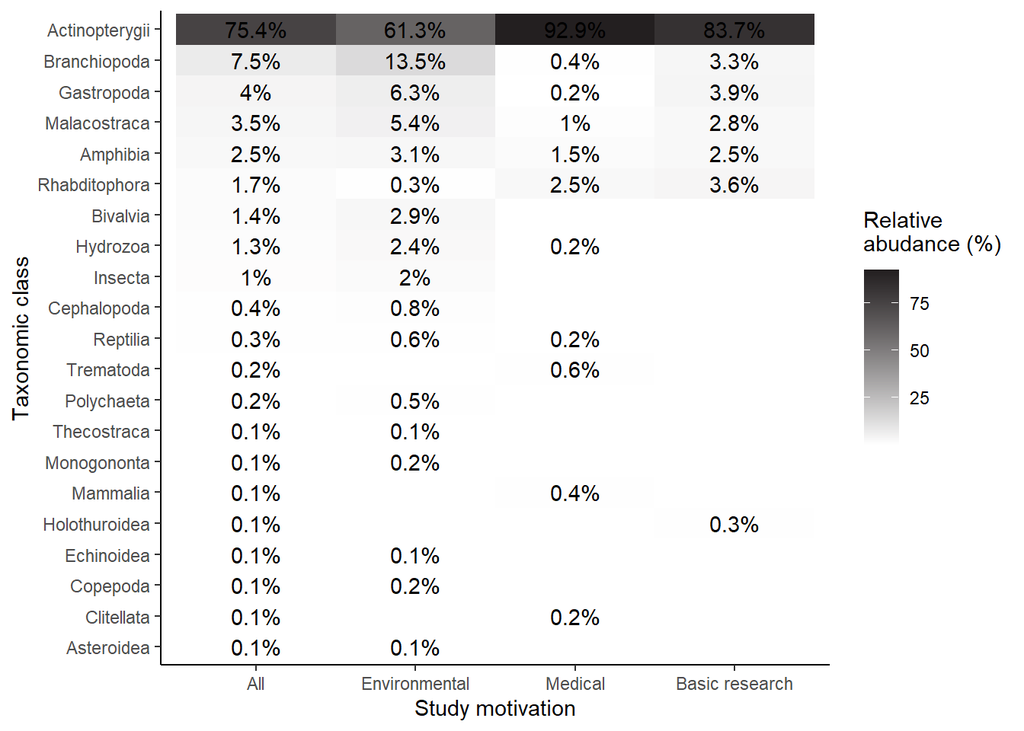

```r
class_order_df <- lineage_count_use %>%
    dplyr::filter(lineage_level == "class") %>%
    dplyr::arrange(classification_percent) %>%
    dplyr::mutate(class_order = 1:nrow(.)) %>%
    dplyr::select(classification, class_order)


class_use_motivation_fig <- lineage_count_use_motivation %>%
    dplyr::filter(lineage_level == "class") %>%
    dplyr::full_join(., class_order_df, by = "classification") %>%
    dplyr::mutate(classification = fct_reorder(classification, class_order), parent = fct_reorder(parent,
        desc(class_order))) %>%
    ggplot(aes(x = study_motivation, y = classification, fill = classification_percent)) +
    geom_tile() + geom_text(aes(label = paste0(round(classification_percent, 1),
    "%"))) + scale_fill_gradient(name = expression("Relative\nabudance (%)"), low = "#FFFFFF",
    high = "#231F20") + theme_classic() + labs(x = "Study motivation", y = "Taxonomic class")
class_use_motivation_fig
```

Save the figure

```r
# setwd(figures_path) ggsave('spp_class_use_motivation_fig.pdf', plot =
# class_use_motivation_fig, width = 5, height = 5)
```

#### 10.6.3.4 Most common species

Let’s see what the most common species were. This is calculated at the population level (i.e. doesn’t count each species mutiple times if multiple compounds were used in a single article; unique_population_id)

```r
n_total <- EIPAAB_database %>%
    dplyr::group_by(unique_population_id) %>%
    dplyr::sample_n(1) %>%
    dplyr::reframe(n = length(unique_population_id)) %>%
    nrow(.)

n_spp <- EIPAAB_database %>%
    dplyr::group_by(unique_population_id, species_ncbi_taxonomy_id) %>%
    dplyr::sample_n(1) %>%
    dplyr::ungroup() %>%
    dplyr::group_by(species_name, species_ncbi_taxonomy_id) %>%
    dplyr::reframe(n = length(species_name), percent = round(n/n_total * 100, 1)) %>%
    dplyr::arrange(desc(n)) %>%
    dplyr::mutate(spp_number = 1:nrow(.))

n_spp %>%
    dplyr::slice(1:15) %>%
    gt()
```

| species_name | species_ncbi_taxonomy_id | n | percent | spp_number |
| --- | --- | --- | --- | --- |
| Danio rerio | NCBI:txid7955 | 412 | 44.1 | 1 |
| Daphnia magna | NCBI:txid35525 | 54 | 5.8 | 2 |
| Pimephales promelas | NCBI:txid90988 | 32 | 3.4 | 3 |
| Betta splendens | NCBI:txid158456 | 26 | 2.8 | 4 |
| Poecilia reticulata | NCBI:txid8081 | 26 | 2.8 | 5 |
| Gambusia holbrooki | NCBI:txid37273 | 18 | 1.9 | 6 |
| Carassius auratus | NCBI:txid7957 | 16 | 1.7 | 7 |
| Oryzias latipes | NCBI:txid8090 | 16 | 1.7 | 8 |
| Gasterosteus aculeatus | NCBI:txid69293 | 14 | 1.5 | 9 |
| Oncorhynchus mykiss | NCBI:txid8022 | 12 | 1.3 | 10 |
| Perca fluviatilis | NCBI:txid8168 | 11 | 1.2 | 11 |
| Xenopus laevis | NCBI:txid8355 | 10 | 1.1 | 12 |
| Salmo trutta | NCBI:txid8032 | 8 | 0.9 | 13 |
| Salmo salar | NCBI:txid8030 | 7 | 0.7 | 14 |
| Sepia officinalis | NCBI:txid6610 | 7 | 0.7 | 15 |

Making a broad category of abundance (article_n_group) to make the summary and figure more digestible

```r
n_spp_fig_data <- n_spp %>%
    dplyr::mutate(species_ncbi_taxonomy_id = fct_reorder(species_ncbi_taxonomy_id,
        desc(n))) %>%
    dplyr::mutate(article_n_group = case_when(n == 1 ~ "One only", n >= 2 & n <=
        5 ~ "Between 2 and 5", n >= 5 & n <= 10 ~ "Between 6 and 10", n >= 10 ~ "Greater than 10",
        TRUE ~ "Others"))
```

This is the number of species in each category

```r
article_n_group_summary <- n_spp_fig_data %>%
    dplyr::group_by(article_n_group) %>%
    dplyr::reframe(n_cat = length(species_name))
article_n_group_summary %>%
    gt()
```

| article_n_group | n_cat |
| --- | --- |
| Between 2 and 5 | 53 |
| Between 6 and 10 | 6 |
| Greater than 10 | 11 |
| One only | 103 |

#### 10.6.3.5 Fig S2

Making a plot to show the distribution of species use in the EIPAAB database

[figure not shown]

```r
n_spp_fig <- n_spp_fig_data %>%
  dplyr::mutate(article_n_group = fct_relevel(article_n_group, "Greater than 10", "Between 6 and 10", "Between 2 and 5", "One only")) %>%
  ggplot(aes(y = n, x = spp_number, color = article_n_group)) +
  geom_line(linewidth = 1, alpha = 0.2) +
  geom_point(stat = "identity", size = 1, alpha = 0.8) +
  scale_color_manual(
    values = c(
    "One only" = "#E94039",
    "Between 2 and 5" = "#F18E76",
    "Between 6 and 10" = "#877FBC",
    "Greater than 10" = "#4D479D"
    ),
  labels = c(
      "One only" = "One only (n = 104)",
      "Between 2 and 5" = "Between 2 and 5 (n = 53)",
      "Between 6 and 10" = "Between 6 and 10 (n = 11)",
      "Greater than 10" = "Greater than 10 (n = 6)"
      )
  ) +  # Set colours for each category
  theme_classic() +
  theme(
    legend.position = c(-0.3, 0.4),  # Positioning the legend inside the plot
    legend.justification = c(-3, 0),   # Bottom left inside the plot
    legend.box.just = "right"
    ) +
  labs(
    x = paste0("Species (1-174)"),
    y = "Number of articles",
    color = "Article number category"
  )

n_spp_fig
```

Save the figure

```r
# setwd(figures_path) ggsave('spp_n_spp_fig.pdf', plot = n_spp_fig, width = 5,
# height = 5)
```

Making a list of the most common 15 species

```r
n_spp_used <- EIPAAB_database %>%
    dplyr::distinct(unique_population_id) %>%
    nrow(.)

top_15_spp_list <- EIPAAB_database %>%
    dplyr::group_by(species_name) %>%
    dplyr::summarise(n = length(unique(unique_population_id)), .groups = "drop") %>%
    dplyr::arrange(desc(n)) %>%
    dplyr::slice(1:15) %>%
    dplyr::pull(species_name) %>%
    as.list()
```

Making a summary dataframe base on study motivation

```r
common_species <- EIPAAB_database %>%
    dplyr::filter(species_name %in% top_15_spp_list) %>%
    dplyr::group_by(species_name, study_motivation) %>%
    dplyr::summarise(n = length(unique(article_id)), .groups = "drop") %>%
    tidyr::complete(species_name, study_motivation, fill = list(n = 0))


species_order <- common_species %>%
    group_by(species_name) %>%
    summarise(total_n = sum(n), .groups = "drop") %>%
    arrange(desc(total_n)) %>%
    ungroup()


common_species <- common_species %>%
    inner_join(species_order, by = "species_name") %>%
    mutate(species_name = fct_reorder(species_name, total_n), study_motivation = fct_relevel(study_motivation,
        "Environmental", "Medical", "Basic research"))
```

#### 10.6.3.6 Fig 3c

A plot of the number of times each of the 15 overall most common species appeared in articles within the EIPAAB databse by study motivation. It’s a little hard to see in the chunk output, try viewing in an external window.

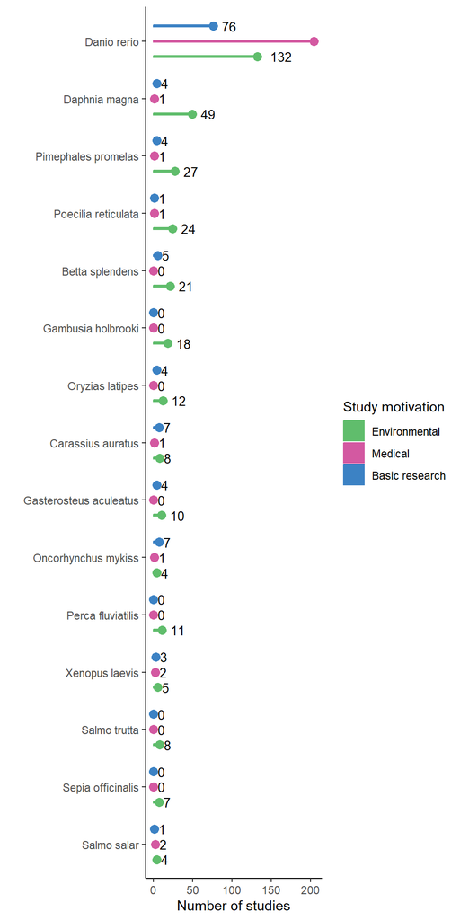

```r
top_15_spp_fig <- common_species %>%
    ggplot(aes(x = species_name, y = n, colour = study_motivation, fill = study_motivation,
        group = study_motivation)) + geom_col(position = position_dodge(width = 0.8),
    width = 0.1) + geom_point(position = position_dodge(width = 0.8), size = 3) +
    geom_text(aes(label = n), hjust = -0.6, size = 3.5, color = "black", position = position_dodge(width = 0.8)) +
    scale_colour_manual(values = motivation_colour_theme, name = "Study motivation") +
    scale_fill_manual(values = motivation_colour_theme, name = "Study motivation") +
    coord_flip() + theme_classic() + labs(x = "", y = "Number of studies") + theme()

top_15_spp_fig
```

Save the figure

```r
# setwd(figures_path) ggsave('spp_top_15_spp_fig.pdf', plot = top_15_spp_fig,
# width = 5, height = 10)
```

Summarising the top 10 in each motivation more specifically

```r
spp_moitivation_summary <- EIPAAB_database %>%
    dplyr::group_by(species_name, study_motivation) %>%
    dplyr::summarise(n = length(unique(unique_population_id)), .groups = "drop") %>%
    tidyr::complete(species_name, study_motivation, fill = list(n = 0)) %>%
    dplyr::group_by(study_motivation) %>%
    dplyr::mutate(total = sum(n)) %>%
    dplyr::ungroup() %>%
    dplyr::mutate(prop = n/total) %>%
    dplyr::select(-total)
```

This plot shows the top 10 in each motivation

```r
top_10_env_spp <- spp_moitivation_summary %>%
    dplyr::filter(study_motivation == "Environmental") %>%
    dplyr::arrange(desc(n)) %>%
    dplyr::slice(1:10) %>%
    dplyr::mutate(species_name = fct_reorder(species_name, n)) %>%
    ggplot(aes(x = species_name, y = n)) + geom_col(width = 0.01, colour = "#60BD6C",
    fill = "#60BD6C") + geom_point(size = 2, colour = "#60BD6C", fill = "#60BD6C") +
    geom_text(aes(label = n), hjust = -0.6, size = 3.5, color = "black") + coord_flip() +
    theme_classic() + labs(x = "", y = "Number of studies", title = "Environmental") +
    theme(plot.title = element_text(size = 12))

top_10_med_spp <- spp_moitivation_summary %>%
    dplyr::filter(study_motivation == "Medical") %>%
    dplyr::arrange(desc(n)) %>%
    dplyr::slice(1:10) %>%
    dplyr::mutate(species_name = fct_reorder(species_name, n)) %>%
    ggplot(aes(x = species_name, y = n)) + geom_col(width = 0.01, colour = "#D359A1",
    fill = "#D359A1") + geom_point(size = 2, colour = "#D359A1", fill = "#D359A1") +
    geom_text(aes(label = n), hjust = -0.6, size = 3.5, color = "black") + coord_flip() +
    theme_classic() + labs(x = "", y = "Number of studies", title = "Medical") +
    theme(plot.title = element_text(size = 12))

top_10_base_spp <- spp_moitivation_summary %>%
    dplyr::filter(study_motivation == "Basic research") %>%
    dplyr::arrange(desc(n)) %>%
    dplyr::slice(1:10) %>%
    dplyr::mutate(species_name = fct_reorder(species_name, n)) %>%
    ggplot(aes(x = species_name, y = n)) + geom_col(width = 0.01, colour = "#3C82C4",
    fill = "#3C82C4") + geom_point(size = 2, colour = "#3C82C4", fill = "#3C82C4") +
    geom_text(aes(label = n), hjust = -0.6, size = 3.5, color = "black") + coord_flip() +
    theme_classic() + labs(x = "", y = "Number of studies", title = "Basic") + theme(plot.title = element_text(size = 12))
```

Here’s a plot to compare the top 10 spp in each study motivation more specifically

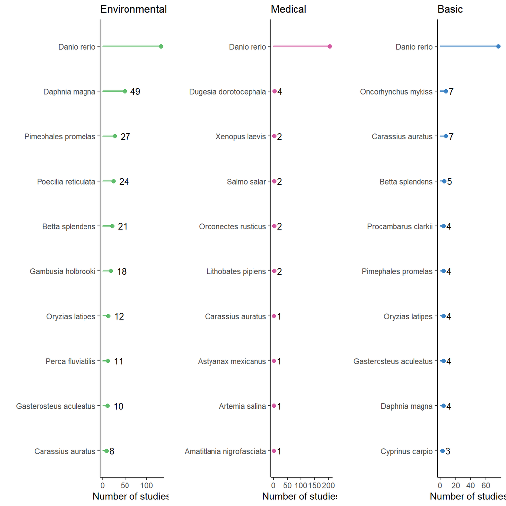

```r
top_10_combind_plot <- grid.arrange(top_10_env_spp, top_10_med_spp, top_10_base_spp,
    ncol = 3)
```

Looking at the number of distinct species used in each motivation group

```r
EIPAAB_database %>%
    dplyr::group_by(study_motivation) %>%
    dplyr::reframe(n_motivation = n_distinct(article_id), n_distinct_spp = n_distinct(species_name)) %>%
    gt()
```

| study_motivation | n_motivation | n_distinct_spp |
| --- | --- | --- |
| Environmental | 510 | 143 |
| Medical | 233 | 25 |
| Basic research | 158 | 43 |

### 10.6.4 Species habitat

First checking how many species have IUCN data, which we will use to assess habitat differences

```r
species_iucn_summary <- EIPAAB_database %>%
    dplyr::group_by(species_name) %>%
    dplyr::sample_n(1) %>%
    dplyr::ungroup() %>%
    dplyr::mutate(species_iucn_bin = if_else(is.na(species_iucn_doi), "No", "Yes")) %>%
    dplyr::group_by(species_iucn_bin) %>%
    dplyr::reframe(n = length(species_iucn_bin))

species_iucn_summary %>%
    gt()
```

| species_iucn_bin | n |
| --- | --- |
| No | 67 |
| Yes | 106 |

Summarising the IUNC habitat type, some species will have multiple habitats, so we split the string by the sepreate (;)

```r
habitat_summary <- EIPAAB_database %>%
  dplyr::group_by(unique_population_id) %>%
  dplyr::sample_n(1) %>% # sampling one row per article per species (i.e. ignoring multiple rows per article for compounds)
  dplyr::ungroup() %>%
  dplyr::group_by(species_iucn_habitat) %>%
  dplyr::reframe(n = n()) %>%
  dplyr::mutate(species_iucn_habitat = str_trim(species_iucn_habitat)) %>%
  tidyr::separate_rows(species_iucn_habitat, sep = ";") %>% # each spp has multiple habitats the string needs spliting
  dplyr::group_by(species_iucn_habitat) %>%
  dplyr::reframe(n_articles = sum(n)) %>% # now a sum for each habitat
  arrange(desc(n_articles))
habitat_summary %>%
  gt()
```

| species_iucn_habitat | n_articles |
| --- | --- |
| Wetlands inland | 738 |
| Artificial or Aquatic and Marine | 187 |
| NA | 164 |
| Marine Neritic | 99 |
| Marine Coastal or Supratidal | 44 |
| Marine Intertidal | 27 |
| Forest | 23 |
| Grassland | 22 |
| Artificial or Terrestrial | 21 |
| Shrubland | 18 |
| Savanna | 13 |
| Marine Oceanic | 10 |
| Unknown | 2 |

Checking how many freshwater vs marine species there are. Wetlands inland categories are freshwater bodies where as Marine have multiple categories (Marine Neritic, Marine Coastal or Supratidal, Marine Intertidal, Marine Oceanic).

```r
habitat_summary %>%
  dplyr::filter(str_starts(species_iucn_habitat, "Marine") | species_iucn_habitat == "Wetlands inland") %>% # Only habitats of interest
  dplyr::mutate(aquatic_type = if_else(species_iucn_habitat == "Wetlands inland", "Freshwater", "Marine")) %>% # New category
  dplyr::group_by(aquatic_type) %>%
  dplyr::reframe(n_articles = sum(n_articles)) %>% # Final sums
  dplyr::ungroup() %>%
  dplyr::mutate(n_total = sum(n_articles),
                percent =  round(n_articles/n_total*100,1)) %>%
  gt()
```

| aquatic_type | n_articles | n_total | percent |
| --- | --- | --- | --- |
| Freshwater | 738 | 918 | 80.4 |
| Marine | 180 | 918 | 19.6 |

Lets break this up by study motivation

```r
habitat_summary_all <- EIPAAB_database %>%
  dplyr::group_by(unique_population_id) %>%
  dplyr::sample_n(1) %>% # sampling one row per article per species (i.e. ignoring multiple rows per article for compounds)
  dplyr::ungroup() %>%
  dplyr::group_by(study_motivation, species_iucn_habitat) %>%
  dplyr::reframe(n = n()) %>%
  dplyr::mutate(species_iucn_habitat = str_trim(species_iucn_habitat)) %>%
  tidyr::separate_rows(species_iucn_habitat, sep = ";") %>% # each spp has multiple habitats the string needs spliting
  dplyr::group_by(species_iucn_habitat, study_motivation) %>%
  dplyr::reframe(n_articles = sum(n)) %>% # now a sum for each habitat
  arrange(desc(n_articles))
habitat_summary_all %>%
  gt()
```

| species_iucn_habitat | study_motivation | n_articles |
| --- | --- | --- |
| Wetlands inland | Environmental | 384 |
| Wetlands inland | Medical | 223 |
| Artificial or Aquatic and Marine | Environmental | 135 |
| Wetlands inland | Basic research | 131 |
| NA | Environmental | 131 |
| Marine Neritic | Environmental | 80 |
| Artificial or Aquatic and Marine | Basic research | 41 |
| Marine Coastal or Supratidal | Environmental | 33 |
| NA | Basic research | 22 |
| Marine Intertidal | Environmental | 19 |
| Artificial or Terrestrial | Environmental | 15 |
| Marine Neritic | Basic research | 15 |
| Grassland | Environmental | 13 |
| Shrubland | Environmental | 13 |
| Forest | Environmental | 12 |
| Artificial or Aquatic and Marine | Medical | 11 |
| NA | Medical | 11 |
| Savanna | Environmental | 8 |
| Forest | Basic research | 7 |
| Marine Coastal or Supratidal | Basic research | 7 |
| Marine Intertidal | Basic research | 7 |
| Grassland | Basic research | 5 |
| Artificial or Terrestrial | Basic research | 4 |
| Forest | Medical | 4 |
| Grassland | Medical | 4 |
| Marine Coastal or Supratidal | Medical | 4 |
| Marine Neritic | Medical | 4 |
| Marine Oceanic | Environmental | 4 |
| Marine Oceanic | Medical | 4 |
| Savanna | Basic research | 3 |
| Shrubland | Basic research | 3 |
| Artificial or Terrestrial | Medical | 2 |
| Marine Oceanic | Basic research | 2 |
| Savanna | Medical | 2 |
| Shrubland | Medical | 2 |
| Unknown | Environmental | 2 |
| Marine Intertidal | Medical | 1 |

Selecting only habitats of interest and allocating to Freshwater or Marine

```r
freshwater_marine <- habitat_summary_all %>%
  dplyr::filter(str_starts(species_iucn_habitat, "Marine") | species_iucn_habitat == "Wetlands inland") %>% # Only habitats of interest
  dplyr::mutate(aquatic_type = if_else(species_iucn_habitat == "Wetlands inland", "Freshwater", "Marine")) %>% # New category
  dplyr::group_by(aquatic_type, study_motivation) %>%
  dplyr::reframe(n_articles = sum(n_articles)) %>% # Final sums
  dplyr::group_by(study_motivation) %>%
  dplyr::mutate(n_cat = sum(n_articles)) %>%
  dplyr::ungroup() %>%
  dplyr::mutate(prop =  n_articles/n_cat) # A proportion of those identify as freshwater vs marine

freshwater_marine %>%
  gt()
```

| aquatic_type | study_motivation | n_articles | n_cat | prop |
| --- | --- | --- | --- | --- |
| Freshwater | Environmental | 384 | 520 | 0.73846154 |
| Freshwater | Medical | 223 | 236 | 0.94491525 |
| Freshwater | Basic research | 131 | 162 | 0.80864198 |
| Marine | Environmental | 136 | 520 | 0.26153846 |
| Marine | Medical | 13 | 236 | 0.05508475 |
| Marine | Basic research | 31 | 162 | 0.19135802 |

Here’s a figure version of this summary

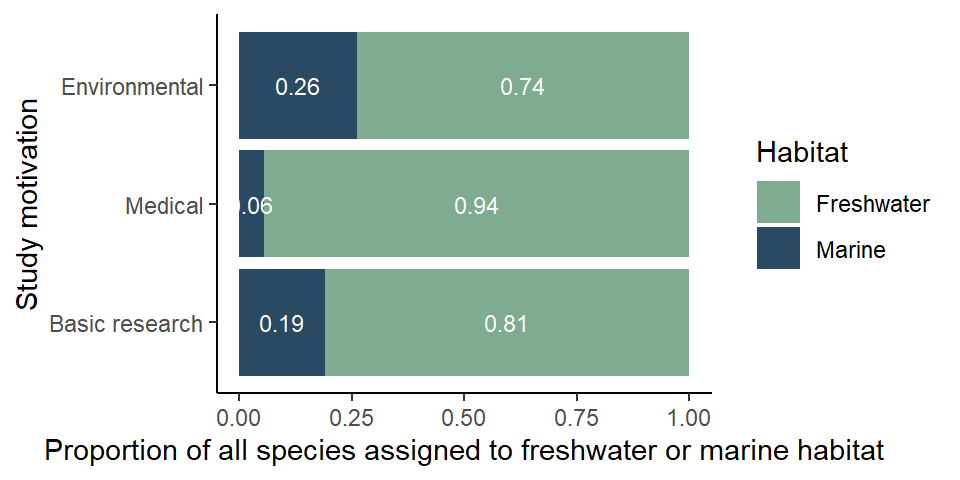

```r
aquatic_type_order <- c("Freshwater", "Marine")

# Calculate cumulative positions for text labels
freshwater_marine <- freshwater_marine %>%
    dplyr::mutate(aquatic_type = factor(aquatic_type, levels = aquatic_type_order)) %>%
    dplyr::group_by(study_motivation) %>%
    dplyr::arrange(desc(aquatic_type)) %>%
    dplyr::mutate(cumulative_prop = cumsum(prop) - prop/2)

# Define the black and grey color theme
color_theme <- c("#7FAB91", "#2A4A64")

# Create the plot
habitat_fig <- freshwater_marine %>%
    mutate(study_motivation = fct_relevel(study_motivation, "Basic research", "Medical",
        "Environmental")) %>%
    ggplot(aes(y = prop, x = study_motivation, fill = aquatic_type, group = aquatic_type)) +
    geom_bar(stat = "identity", width = 0.9) + geom_text(aes(label = round(prop,
    2), y = cumulative_prop), color = "white", size = 3) + scale_fill_manual(values = color_theme,
    name = "Habitat") + theme_classic() + theme(legend.position = "right") + labs(x = "Study motivation",
    y = "Proportion of all species assigned to freshwater or marine habitat") + coord_flip()

habitat_fig
```

Save the figure

```r
# setwd(figures_path) ggsave('spp_habitat_fig.pdf', plot = habitat_fig, width =
# 10, height = 5)
```

We should also consider how many records did not inculde IUCN reports and thus habitat.

Let’s make a plot that shows how many didn’t have an assigned IUNC habitat. To add to the above figure.

```r
no_habitat <- EIPAAB_database %>%
  dplyr::group_by(unique_population_id) %>%
  dplyr::sample_n(1) %>% # sampling one row per article per species (i.e. ignoring multiple rows per article for compounds)
  dplyr::ungroup() %>%
  dplyr::mutate(species_iucn_bin = if_else(is.na(species_iucn_doi), "No", "Yes")) %>%
  dplyr::group_by(species_iucn_bin) %>%
  dplyr::reframe(n = length(species_iucn_bin))


n_total <- EIPAAB_database %>%
  dplyr::group_by(unique_population_id) %>%
  dplyr::sample_n(1) %>% # sampling one row per article per species (i.e. ignoring multiple rows per article for compounds)
  dplyr::ungroup() %>%
  nrow(.)

no_habitat <- no_habitat %>%
  dplyr::mutate(prop = n/n_total)

no_habitat %>%
  gt()
```

| species_iucn_bin | n | prop |
| --- | --- | --- |
| No | 163 | 0.1743316 |
| Yes | 772 | 0.8256684 |

Here’s the plot

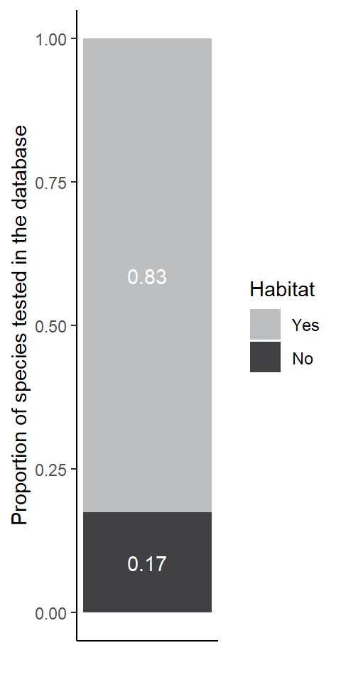

```r
# Define the black and grey color theme
black_and_grey <- c("#BCBEC0", "#414042")

yes_order <- c("Yes", "No")

# Calculate cumulative positions for text labels
habitat_info_df_fig <- no_habitat %>%
  dplyr::mutate(species_iucn_bin = factor(species_iucn_bin, levels = yes_order)) %>%
  dplyr::arrange(desc(species_iucn_bin)) %>%
  dplyr::mutate(cumulative_prop = cumsum(prop) - prop / 2)

habitat_info_fig <- habitat_info_df_fig %>%
  dplyr::mutate(species_iucn_bin = factor(species_iucn_bin, levels = yes_order)) %>%
  ggplot(aes(y = prop, x = 1, fill = species_iucn_bin)) +
  geom_bar(stat = "identity", width = 0.1) +
  geom_text(aes(label = round(prop, 2), y = cumulative_prop), color = "white") +
  scale_fill_manual(values = black_and_grey, name = "Habitat") +
  theme_classic() +
  theme(legend.position = "right",
        axis.text.x = element_blank(),  # Remove x-axis text
        axis.ticks.x = element_blank()  # Remove x-axis ticks
        ) +
  labs(
    x = "",
    y = "Proportion of species tested in the database"
  )
habitat_info_fig
```

Save the plot

```r
# setwd(figures_path) ggsave('spp_habitat_info_fig.pdf', plot =
# habitat_info_fig, width = 5, height = 10)
```

### 10.6.5 Species life satge

Let’s get an overall summary first, without Unknown or not specified life stages

```r
EIPAAB_database %>%
  dplyr::group_by(unique_population_id) %>%
  dplyr::sample_n(1) %>% # sampling one row per article per species (i.e. ignoring multiple rows per article for compounds)
  dplyr::ungroup() %>%
  dplyr::group_by(species_stage) %>%
  dplyr::reframe(n = n()) %>%
  dplyr::mutate(species_stage = str_trim(species_stage)) %>%
  tidyr::separate_rows(species_stage, sep = ";") %>% # each spp has multiple habitats the string needs splitting
  dplyr::filter(species_stage != "Unknown or not specified") %>%
  dplyr::group_by(species_stage) %>%
  dplyr::reframe(n_articles = sum(n)) %>%  # now a sum for each habitat
  dplyr::mutate(total_stages = sum(n_articles)) %>%
  dplyr::ungroup() %>%
  dplyr::mutate(overall_percent = round(n_articles/total_stages*100,1)) %>%
  gt()
```

| species_stage | n_articles | total_stages | overall_percent |
| --- | --- | --- | --- |
| Adult | 443 | 831 | 53.3 |
| Egg or embryo | 46 | 831 | 5.5 |
| Juvenile | 123 | 831 | 14.8 |
| Larvae | 219 | 831 | 26.4 |

Let’s take a look at spp life stages used in the EIPAAB database on study motivation

First those that didn’t report it

```r
stage_summary_all <- EIPAAB_database %>%
  dplyr::group_by(unique_population_id) %>%
  dplyr::sample_n(1) %>% # sampling one row per article per species (i.e. ignoring multiple rows per article for compounds)
  dplyr::ungroup() %>%
  dplyr::group_by(study_motivation, species_stage) %>%
  dplyr::reframe(n = n()) %>%
  dplyr::mutate(species_stage = str_trim(species_stage)) %>%
  tidyr::separate_rows(species_stage, sep = ";") %>% # each spp has multiple habitats the string needs splitting
  dplyr::group_by(species_stage, study_motivation) %>%
  dplyr::reframe(n_total = sum(n)) %>%  # now a sum for each habitat
  dplyr::group_by(study_motivation) %>%
  dplyr::mutate(n_motivation = sum(n_total),
                percent = round(n_total/n_motivation*100,1)) %>%
  dplyr::ungroup()

stage_summary_all %>%
  dplyr::filter(species_stage == "Unknown or not specified") %>%
  dplyr::mutate(percent_reported = 100-percent) %>%
  dplyr::rename(percent_not_report = percent) %>%
  gt()
```

| species_stage | study_motivation | n_total | n_motivation | percent_not_report | percent_reported |
| --- | --- | --- | --- | --- | --- |
| Unknown or not specified | Environmental | 100 | 586 | 17.1 | 82.9 |
| Unknown or not specified | Medical | 22 | 245 | 9.0 | 91.0 |
| Unknown or not specified | Basic research | 44 | 166 | 26.5 | 73.5 |

A table by study motivation and age class

```r
stage_order <- c("Adult", "Juvenile", "Larvae", "Egg or embryo")

stage_summary_reported <- stage_summary_all %>%
    dplyr::filter(species_stage != "Unknown or not specified") %>%
    dplyr::group_by(study_motivation) %>%
    dplyr::mutate(n_motivation = sum(n_total), percent = round(n_total/n_motivation *
        100, 1), species_stage = factor(species_stage, levels = stage_order)) %>%
    dplyr::ungroup() %>%
    dplyr::arrange(species_stage)

stage_summary_reported %>%
    gt()
```

| species_stage | study_motivation | n_total | n_motivation | percent |
| --- | --- | --- | --- | --- |
| Adult | Environmental | 236 | 486 | 48.6 |
| Adult | Medical | 134 | 223 | 60.1 |
| Adult | Basic research | 73 | 122 | 59.8 |
| Juvenile | Environmental | 92 | 486 | 18.9 |
| Juvenile | Medical | 14 | 223 | 6.3 |
| Juvenile | Basic research | 17 | 122 | 13.9 |
| Larvae | Environmental | 127 | 486 | 26.1 |
| Larvae | Medical | 64 | 223 | 28.7 |
| Larvae | Basic research | 28 | 122 | 23.0 |
| Egg or embryo | Environmental | 31 | 486 | 6.4 |
| Egg or embryo | Medical | 11 | 223 | 4.9 |
| Egg or embryo | Basic research | 4 | 122 | 3.3 |

Same data presented as a figure

For life stages that are described, what is the breakdown

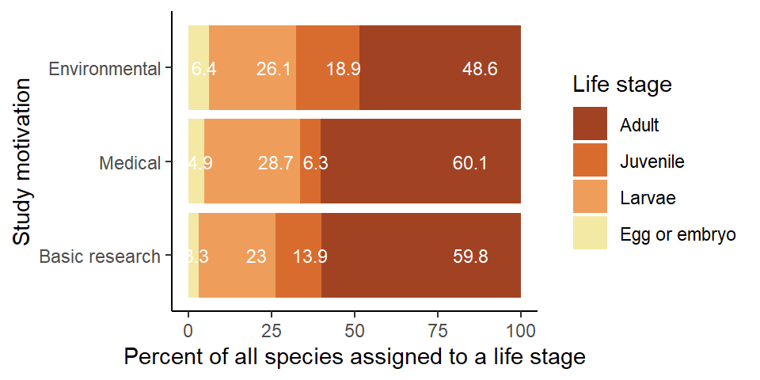

```r
# Define the black and grey color theme
color_theme <- c("#A14323", "#D86C2F", "#EE9E5A", "#F3E9A5")


# Calculate cumulative positions for text labels
stage_summary_reported <- stage_summary_reported %>%
    dplyr::group_by(study_motivation) %>%
    dplyr::arrange(desc(species_stage)) %>%
    dplyr::mutate(cumulative_percent = cumsum(percent) - percent/4)

# Create the plot
life_stage_fig <- stage_summary_reported %>%
    mutate(study_motivation = fct_relevel(study_motivation, "Basic research", "Medical",
        "Environmental")) %>%
    ggplot(aes(y = percent, x = study_motivation, fill = species_stage, group = species_stage)) +
    geom_bar(stat = "identity", width = 0.9) + geom_text(aes(label = percent, y = cumulative_percent),
    color = "white", size = 3) + scale_fill_manual(values = color_theme, name = "Life stage") +
    theme_classic() + theme(legend.position = "right") + labs(x = "Study motivation",
    y = "Percent of all species assigned to a life stage") + coord_flip()

life_stage_fig
```

Save the figure

```r
# setwd(figures_path) ggsave('spp_life_stage_fig.pdf', plot = life_stage_fig,
# width = 10, height = 5)
```

Let’s also look at how many where unknown or not described overall

```r
stage_summary_info <- stage_summary_all %>%
    dplyr::mutate(stage_reported = if_else(species_stage == "Unknown or not specified",
        "No", "Yes")) %>%
    dplyr::group_by(stage_reported) %>%
    dplyr::reframe(n = sum(n_total))

n_total <- stage_summary_info %>%
    dplyr::reframe(n_total = sum(n)) %>%
    pull(n_total)

stage_summary_info <- stage_summary_info %>%
    dplyr::mutate(prop = n/n_total)
```

Here’s the plot

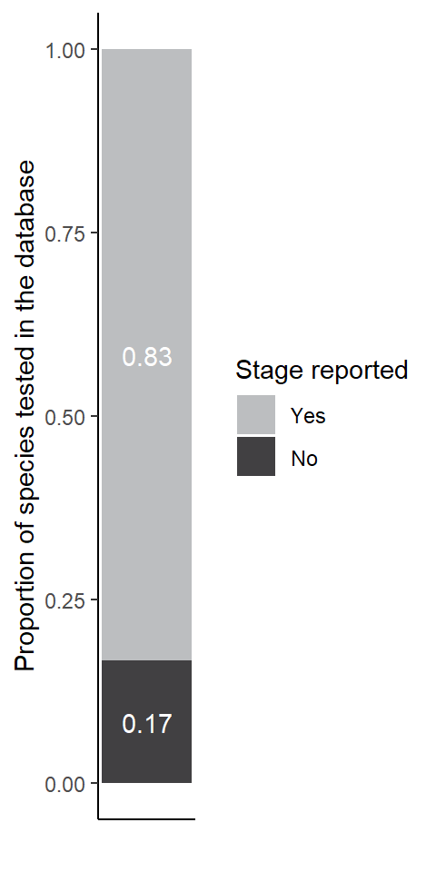

```r
# Define the black and grey color theme
black_and_grey <- c("#BCBEC0", "#414042")

yes_order <- c("Yes", "No")

# Calculate cumulative positions for text labels
stage_summary_info <- stage_summary_info %>%
  dplyr::mutate(stage_reported = factor(stage_reported, levels = yes_order)) %>%
  dplyr::arrange(desc(stage_reported)) %>%
  dplyr::mutate(cumulative_prop = cumsum(prop) - prop / 2)

stage_info_fig <- stage_summary_info %>%
  dplyr::mutate(stage_reported = factor(stage_reported, levels = yes_order)) %>%
  ggplot(aes(y = prop, x = 1, fill = stage_reported)) +
  geom_bar(stat = "identity", width = 0.9) +
  geom_text(aes(label = round(prop, 2), y = cumulative_prop), color = "white") +
  scale_fill_manual(values = black_and_grey, name = "Stage reported") +
  theme_classic() +
  theme(legend.position = "right",
        axis.text.x = element_blank(),  # Remove x-axis text
        axis.ticks.x = element_blank()  # Remove x-axis ticks
  ) +
  labs(
    x = "",
    y = "Proportion of species tested in the database"
  )
stage_info_fig
```

Save the figure

```r
# setwd(figures_path) ggsave('spp_stage_info_fig.pdf', plot = stage_info_fig,
# width = 2.5, height = 5)
```

### 10.6.6 Species sex

First overall breakdown by female and male without including unreported or hermaphroditic animals

```r
EIPAAB_database %>%
  dplyr::group_by(unique_population_id) %>%
  dplyr::sample_n(1) %>% # sampling one row per article per species (i.e. ignoring multiple rows per article for compounds)
  dplyr::ungroup() %>%
  dplyr::group_by(species_sex) %>%
  dplyr::reframe(n = n()) %>%
  dplyr::mutate(species_sex = str_trim(species_sex)) %>%
  tidyr::separate_rows(species_sex, sep = ";") %>% # each spp has multiple habitats the string needs splitting
  dplyr::group_by(species_sex) %>%
  dplyr::summarise(n_articles = sum(n), .groups = 'drop') %>%  # now a sum for each habitat
  tidyr::complete(species_sex,
                  fill = list(n_articles = 0)) %>%  # make a full df with empty categories = 0
  dplyr::ungroup() %>%
  dplyr::filter(species_sex == "Female" | species_sex == "Male") %>%
  dplyr::mutate(total_sex = sum(n_articles)) %>%
  dplyr::ungroup() %>%
  dplyr::mutate(overall_percent = round(n_articles/total_sex*100,1)) %>%
  gt()
```

| species_sex | n_articles | total_sex | overall_percent |
| --- | --- | --- | --- |
| Female | 280 | 623 | 44.9 |
| Male | 343 | 623 | 55.1 |

Let’s take a look at the sex of spp used in the EIPAAB database

```r
sex_summary_all <- EIPAAB_database %>%
  dplyr::group_by(unique_population_id) %>%
  dplyr::sample_n(1) %>% # sampling one row per article per species (i.e. ignoring multiple rows per article for compounds)
  dplyr::ungroup() %>%
  dplyr::group_by(study_motivation, species_sex) %>%
  dplyr::reframe(n = n()) %>%
  dplyr::mutate(species_sex = str_trim(species_sex)) %>%
  tidyr::separate_rows(species_sex, sep = ";") %>% # each spp has multiple habitats the string needs splitting
  dplyr::group_by(species_sex, study_motivation) %>%
  dplyr::summarise(n_articles = sum(n), .groups = 'drop') %>%  # now a sum for each habitat
  tidyr::complete(species_sex, study_motivation,
                  fill = list(n_articles = 0)) %>%  # make a full df with empty categories = 0
  dplyr::ungroup() %>%
  dplyr::group_by(study_motivation) %>%
  dplyr::mutate(total_sex = sum(n_articles)) %>%
  dplyr::ungroup() %>%
  dplyr::mutate(overall_prop = n_articles/total_sex)
sex_summary_all %>%
  gt()
```

| species_sex | study_motivation | n_articles | total_sex | overall_prop |
| --- | --- | --- | --- | --- |
| Female | Environmental | 136 | 645 | 0.21085271 |
| Female | Medical | 91 | 322 | 0.28260870 |
| Female | Basic research | 53 | 206 | 0.25728155 |
| Hermaphrodites | Environmental | 4 | 645 | 0.00620155 |
| Hermaphrodites | Medical | 0 | 322 | 0.00000000 |
| Hermaphrodites | Basic research | 0 | 206 | 0.00000000 |
| Male | Environmental | 180 | 645 | 0.27906977 |
| Male | Medical | 99 | 322 | 0.30745342 |
| Male | Basic research | 64 | 206 | 0.31067961 |
| Unknown or not specified | Environmental | 325 | 645 | 0.50387597 |
| Unknown or not specified | Medical | 132 | 322 | 0.40993789 |
| Unknown or not specified | Basic research | 89 | 206 | 0.43203883 |

Let’s look at just the proportion of those defined as male and female

```r
sex_male_female <- sex_summary_all %>%
    dplyr::filter(species_sex == "Female" | species_sex == "Male") %>%
    dplyr::select(-total_sex, -overall_prop) %>%
    dplyr::group_by(study_motivation) %>%
    dplyr::mutate(total_male_female = sum(n_articles)) %>%
    dplyr::ungroup() %>%
    dplyr::mutate(percent = round(n_articles/total_male_female * 100, 1))

sex_male_female %>%
    gt()
```

| species_sex | study_motivation | n_articles | total_male_female | percent |
| --- | --- | --- | --- | --- |
| Female | Environmental | 136 | 316 | 43.0 |
| Female | Medical | 91 | 190 | 47.9 |
| Female | Basic research | 53 | 117 | 45.3 |
| Male | Environmental | 180 | 316 | 57.0 |
| Male | Medical | 99 | 190 | 52.1 |
| Male | Basic research | 64 | 117 | 54.7 |

Making the plot

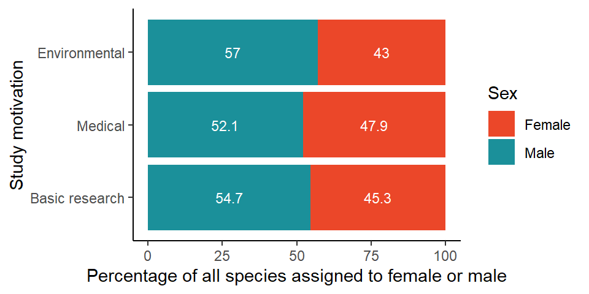

```r
sex_order <- c("Female", "Male")

color_theme <- c("#eb4729", "#1b909a")

# Calculate cumulative positions for text labels
sex_male_female <- sex_male_female %>%
    dplyr::mutate(species_sex = factor(species_sex, levels = sex_order)) %>%
    dplyr::group_by(study_motivation) %>%
    dplyr::arrange(desc(species_sex)) %>%
    dplyr::mutate(cumulative_percent = cumsum(percent) - percent/2)

# Create the plot
sex_fig <- sex_male_female %>%
    mutate(study_motivation = fct_relevel(study_motivation, "Basic research", "Medical",
        "Environmental")) %>%
    ggplot(aes(y = percent, x = study_motivation, fill = species_sex, group = species_sex)) +
    geom_bar(stat = "identity", width = 0.9) + geom_text(aes(label = round(percent,
    2), y = cumulative_percent), color = "white", size = 3) + scale_fill_manual(values = color_theme,
    name = "Sex") + theme_classic() + theme(legend.position = "right") + labs(x = "Study motivation",
    y = "Percentage of all species assigned to female or male") + coord_flip()

sex_fig
```

Save the figure

```r
# setwd(figures_path) ggsave('spp_sex_fig.pdf', plot = sex_fig, width = 10,
# height = 5)
```

Now let’s look at those not assigned to a sex

```r
sex_summary_info <- sex_summary_all %>%
    dplyr::mutate(sex_reported = if_else(species_sex == "Unknown or not specified",
        "No", "Yes")) %>%
    dplyr::group_by(sex_reported) %>%
    dplyr::reframe(n = sum(n_articles))

n_total <- sex_summary_info %>%
    dplyr::reframe(n_total = sum(n)) %>%
    dplyr::pull(n_total)

sex_summary_info <- sex_summary_info %>%
    dplyr::mutate(prop = n/n_total)
```

Here’s the plot

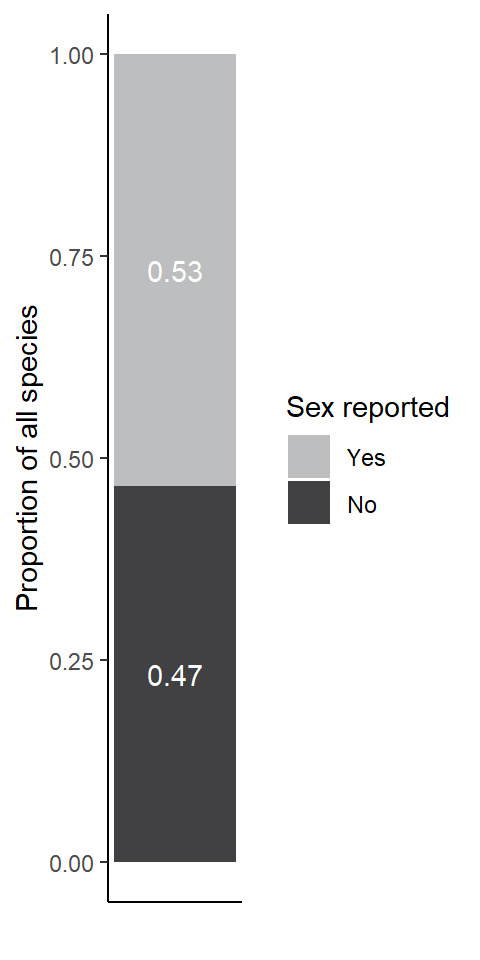

```r
# Define the black and grey color theme
black_and_grey <- c("#BCBEC0", "#414042")

yes_order <- c("Yes", "No")

# Calculate cumulative positions for text labels
sex_summary_info <- sex_summary_info %>%
  dplyr::mutate(sex_reported = factor(sex_reported, levels = yes_order)) %>%
  dplyr::arrange(desc(sex_reported)) %>%
  dplyr::mutate(cumulative_prop = cumsum(prop) - prop / 2)

sex_info_fig <- sex_summary_info %>%
  dplyr::mutate(sex_reported = factor(sex_reported, levels = yes_order)) %>%
  ggplot(aes(y = prop, x = 1, fill = sex_reported)) +
  geom_bar(stat = "identity", width = 0.9) +
  geom_text(aes(label = round(prop, 2), y = cumulative_prop), color = "white") +
  scale_fill_manual(values = black_and_grey, name = "Sex reported") +
  theme_classic() +
  theme(legend.position = "right",
        axis.text.x = element_blank(),  # Remove x-axis text
        axis.ticks.x = element_blank()  # Remove x-axis ticks
        ) +
  labs(
    x = "",
    y = "Proportion of all species"
  )
sex_info_fig
```

Save the figure

```r
# setwd(figures_path) ggsave('spp_sex_info_fig.pdf', plot = sex_info_fig, width
# = 2.5, height = 5)
```

### 10.6.7 Species source

Breakdown without unreported

```r
EIPAAB_database %>%
  dplyr::group_by(unique_population_id) %>%
  dplyr::sample_n(1) %>% # sampling one row per article per species (i.e. ignoring multiple rows per article for compounds)
  dplyr::ungroup() %>%
  dplyr::group_by(species_source) %>%
  dplyr::reframe(n = n()) %>%
  dplyr::mutate(species_source = str_trim(species_source)) %>%
  tidyr::separate_rows(species_source, sep = ";") %>% # each spp has multiple habitats the string needs splitting
  dplyr::group_by(species_source) %>%
  dplyr::summarise(n_articles = sum(n), .groups = 'drop') %>%  # now a sum for each habitat
  tidyr::complete(species_source,
                  fill = list(n_articles = 0)) %>%  # make a full df with empty categories = 0
  dplyr::filter(species_source != "Not reported") %>%
  dplyr::ungroup() %>%
  dplyr::mutate(total_source = sum(n_articles)) %>%
  dplyr::ungroup() %>%
  dplyr::mutate(overall_percent = round(n_articles/total_source*100, 1)) %>%
  dplyr::arrange(desc(overall_percent)) %>%
  gt()
```

| species_source | n_articles | total_source | overall_percent |
| --- | --- | --- | --- |
| Commercial supplier or fish farm | 306 | 802 | 38.2 |
| Lab stock of undisclosed origin | 213 | 802 | 26.6 |
| Wild collected | 195 | 802 | 24.3 |
| Lab stock from commercial supplier | 55 | 802 | 6.9 |
| Lab stock from wild population | 33 | 802 | 4.1 |

Let’s look at where the animals were sourced for articles in the EIPAAB database

```r
source_summary_all <- EIPAAB_database %>%
  dplyr::group_by(unique_population_id) %>%
  dplyr::sample_n(1) %>% # sampling one row per article per species (i.e. ignoring multiple rows per article for compounds)
  dplyr::ungroup() %>%
  dplyr::group_by(study_motivation, species_source) %>%
  dplyr::reframe(n = n()) %>%
  dplyr::mutate(species_source = str_trim(species_source)) %>%
  tidyr::separate_rows(species_source, sep = ";") %>% # each spp has multiple habitats the string needs splitting
  dplyr::group_by(species_source, study_motivation) %>%
  dplyr::summarise(n_articles = sum(n), .groups = 'drop') %>%  # now a sum for each habitat
  tidyr::complete(species_source, study_motivation,
                  fill = list(n_articles = 0)) %>%  # make a full df with empty categories = 0
  dplyr::ungroup() %>%
  dplyr::group_by(study_motivation) %>%
  dplyr::mutate(total_source = sum(n_articles)) %>%
  dplyr::ungroup() %>%
  dplyr::mutate(overall_percent = round(n_articles/total_source*100,1))

source_summary_all %>%
  gt()
```

| species_source | study_motivation | n_articles | total_source | overall_percent |
| --- | --- | --- | --- | --- |
| Commercial supplier or fish farm | Environmental | 134 | 548 | 24.5 |
| Commercial supplier or fish farm | Medical | 101 | 240 | 42.1 |
| Commercial supplier or fish farm | Basic research | 71 | 162 | 43.8 |
| Lab stock from commercial supplier | Environmental | 29 | 548 | 5.3 |
| Lab stock from commercial supplier | Medical | 16 | 240 | 6.7 |
| Lab stock from commercial supplier | Basic research | 10 | 162 | 6.2 |
| Lab stock from wild population | Environmental | 25 | 548 | 4.6 |
| Lab stock from wild population | Medical | 1 | 240 | 0.4 |
| Lab stock from wild population | Basic research | 7 | 162 | 4.3 |
| Lab stock of undisclosed origin | Environmental | 119 | 548 | 21.7 |
| Lab stock of undisclosed origin | Medical | 63 | 240 | 26.2 |
| Lab stock of undisclosed origin | Basic research | 31 | 162 | 19.1 |
| Not reported | Environmental | 72 | 548 | 13.1 |
| Not reported | Medical | 51 | 240 | 21.2 |
| Not reported | Basic research | 25 | 162 | 15.4 |
| Wild collected | Environmental | 169 | 548 | 30.8 |
| Wild collected | Medical | 8 | 240 | 3.3 |
| Wild collected | Basic research | 18 | 162 | 11.1 |

Only those with reported source

```r
source_order <- c("Wild collected", "Lab stock from wild population", "Lab stock of undisclosed origin",
    "Lab stock from commercial supplier", "Commercial supplier or fish farm")

source_summary <- source_summary_all %>%
    dplyr::filter(species_source != "Not reported") %>%
    dplyr::select(species_source, study_motivation, n_articles) %>%
    dplyr::group_by(study_motivation) %>%
    dplyr::mutate(total_reported = sum(n_articles)) %>%
    dplyr::ungroup() %>%
    dplyr::mutate(percent = round(n_articles/total_reported * 100, 1), species_source = factor(species_source,
        levels = source_order)) %>%
    dplyr::arrange(species_source)

source_summary %>%
    gt()
```

| species_source | study_motivation | n_articles | total_reported | percent |
| --- | --- | --- | --- | --- |
| Wild collected | Environmental | 169 | 476 | 35.5 |
| Wild collected | Medical | 8 | 189 | 4.2 |
| Wild collected | Basic research | 18 | 137 | 13.1 |
| Lab stock from wild population | Environmental | 25 | 476 | 5.3 |
| Lab stock from wild population | Medical | 1 | 189 | 0.5 |
| Lab stock from wild population | Basic research | 7 | 137 | 5.1 |
| Lab stock of undisclosed origin | Environmental | 119 | 476 | 25.0 |
| Lab stock of undisclosed origin | Medical | 63 | 189 | 33.3 |
| Lab stock of undisclosed origin | Basic research | 31 | 137 | 22.6 |
| Lab stock from commercial supplier | Environmental | 29 | 476 | 6.1 |
| Lab stock from commercial supplier | Medical | 16 | 189 | 8.5 |
| Lab stock from commercial supplier | Basic research | 10 | 137 | 7.3 |
| Commercial supplier or fish farm | Environmental | 134 | 476 | 28.2 |
| Commercial supplier or fish farm | Medical | 101 | 189 | 53.4 |
| Commercial supplier or fish farm | Basic research | 71 | 137 | 51.8 |

A figure with the same information

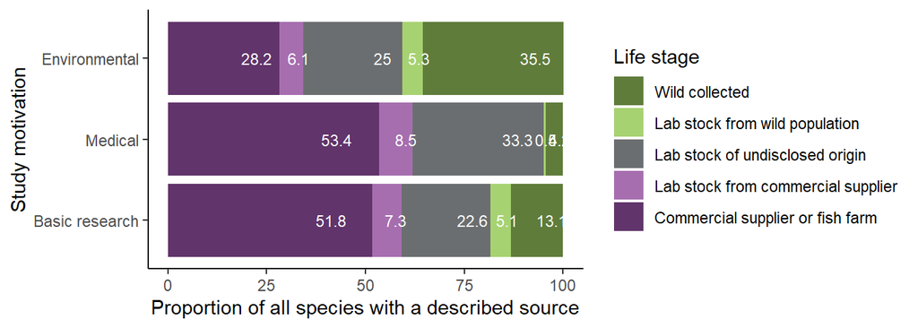

```r
source_order <- c("Wild collected", "Lab stock from wild population", "Lab stock of undisclosed origin",
    "Lab stock from commercial supplier", "Commercial supplier or fish farm")

# Define the black and grey color theme
color_theme <- c("#607C3B", "#A7D271", "#6B6E70", "#A66EAF", "#61346B")

# Calculate cumulative positions for text labels
source_summary <- source_summary %>%
    dplyr::group_by(study_motivation) %>%
    dplyr::arrange(desc(species_source)) %>%
    dplyr::mutate(cumulative_percent = cumsum(percent) - percent/5)

# Create the plot
source_fig <- source_summary %>%
    mutate(study_motivation = fct_relevel(study_motivation, "Basic research", "Medical",
        "Environmental")) %>%
    ggplot(aes(y = percent, x = study_motivation, fill = species_source, group = species_source)) +
    geom_bar(stat = "identity", width = 0.9) + geom_text(aes(label = round(percent,
    2), y = cumulative_percent), color = "white", size = 3) + scale_fill_manual(values = color_theme,
    name = "Life stage") + theme_classic() + theme(legend.position = "right") + labs(x = "Study motivation",
    y = "Proportion of all species with a described source") + coord_flip()

source_fig
```

Save the figure

```r
# setwd(figures_path) ggsave('spp_source_fig.pdf', plot = source_fig, width =
# 10, height = 5)
```

Now let’s look at those not assigned a source

```r
source_summary_info <- source_summary_all %>%
    dplyr::mutate(source_reported = if_else(species_source == "Not reported", "No",
        "Yes")) %>%
    dplyr::group_by(source_reported) %>%
    dplyr::reframe(n = sum(n_articles))

n_total <- source_summary_info %>%
    dplyr::reframe(n_total = sum(n)) %>%
    dplyr::pull(n_total)

source_summary_info <- source_summary_info %>%
    dplyr::mutate(prop = n/n_total)
```

Here’s the plot

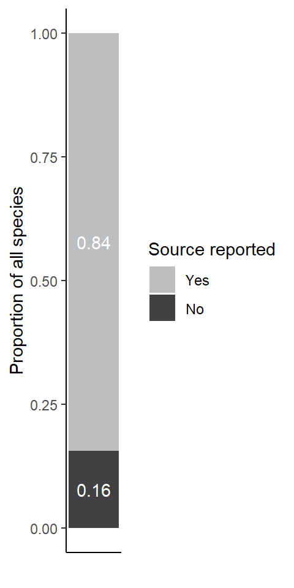

```r
# Define the black and grey color theme
black_and_grey <- c("#BCBEC0", "#414042")

yes_order <- c("Yes", "No")

# Calculate cumulative positions for text labels
source_summary_info <- source_summary_info %>%
  dplyr::mutate(source_reported = factor(source_reported, levels = yes_order)) %>%
  dplyr::arrange(desc(source_reported)) %>%
  dplyr::mutate(cumulative_prop = cumsum(prop) - prop / 2)

source_info_fig <- source_summary_info %>%
  dplyr::mutate(source_reported = factor(source_reported, levels = yes_order)) %>%
  ggplot(aes(y = prop, x = 1, fill = source_reported)) +
  geom_bar(stat = "identity", width = 0.9) +
  geom_text(aes(label = round(prop, 2), y = cumulative_prop), color = "white") +
  scale_fill_manual(values = black_and_grey, name = "Source reported") +
  theme_classic() +
  theme(legend.position = "right",
        axis.text.x = element_blank(),  # Remove x-axis text
        axis.ticks.x = element_blank()  # Remove x-axis ticks
        ) +
  labs(
    x = "",
    y = "Proportion of all species"
  )
source_info_fig
```

Save the figure

```r
# setwd(figures_path) ggsave('spp_source_info_fig.pdf', plot = source_info_fig,
# width = 5, height = 10)
```

## 10.7 Compounds

### 10.7.1 Number of compounds in database

There are 426 distinct compounds in the database

```r
EIPAAB_database %>%
    dplyr::distinct(compound_name) %>%
    nrow()
```

```
## [1] 426
```

#### 10.7.1.1 Number of compounds per study

```r
article_n <- EIPAAB_database %>%
  dplyr::distinct(article_id) %>%
  nrow(.)

compound_n_summary <- EIPAAB_database %>%
  dplyr::group_by(article_id) %>%
  dplyr::sample_n(1) %>%
  dplyr::ungroup() %>%
  dplyr::group_by(compound_n) %>%
  dplyr::reframe(n = n(),
                   percent = round((n/article_n)*100,1))

compound_n_summary %>%
  dplyr::slice(1:10) %>%  #10 most common number of compounds
  gt()
```

| compound_n | n | percent |
| --- | --- | --- |
| 1 | 624 | 69.3 |
| 2 | 127 | 14.1 |
| 3 | 67 | 7.4 |
| 4 | 32 | 3.6 |
| 5 | 16 | 1.8 |
| 6 | 8 | 0.9 |
| 7 | 6 | 0.7 |
| 8 | 5 | 0.6 |
| 9 | 1 | 0.1 |
| 10 | 2 | 0.2 |

How many used more then 5

```r
compound_n_summary %>%
    dplyr::filter(compound_n > 5) %>%
    reframe(n = sum(n), percent = round((n/article_n) * 100, 1)) %>%
    gt()
```

| n | percent |
| --- | --- |
| 35 | 3.9 |

By motivation summary data frame

```r
compound_n_summary <- EIPAAB_database %>%
    dplyr::group_by(article_id) %>%
    dplyr::sample_n(1) %>%
    dplyr::ungroup() %>%
    dplyr::group_by(compound_n, study_motivation) %>%
    dplyr::summarise(n = n(), .groups = "drop") %>%
    tidyr::complete(compound_n, study_motivation, fill = list(n = 0)) %>%
    dplyr::group_by(study_motivation) %>%
    dplyr::mutate(total_motivation = sum(n)) %>%
    dplyr::ungroup() %>%
    dplyr::mutate(prop_motivation = n/total_motivation)
```

#### 10.7.1.2 Fig S4

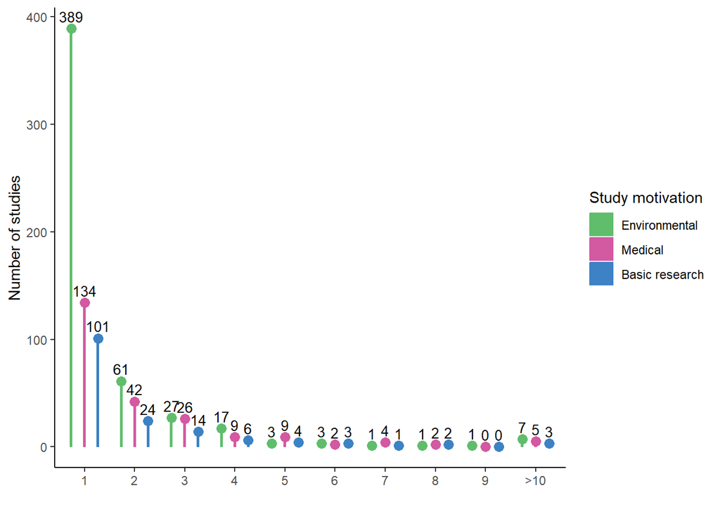

```r
# Define the colour palette
motivation_colour_theme <- c("#60BD6C", "#D359A1", "#3C82C4") # Making colour theme to apply to plot

compound_n_oder <- c(1:9, ">10")

compound_n_fig <- compound_n_summary %>%
  dplyr::mutate(
    compound_n = as.character(if_else(compound_n > 10, 10, compound_n)), # Grouping cases above 10
    compound_n = if_else(compound_n == "10", ">10", compound_n)
    ) %>%
  dplyr::group_by(compound_n, study_motivation) %>%
  dplyr::reframe(n = sum(n)) %>%
  dplyr::mutate(compound_n = factor(compound_n, levels = compound_n_oder)) %>%
  ggplot(aes(x=compound_n, y=n, colour = study_motivation, fill = study_motivation, group = study_motivation)) +
  geom_col(position = position_dodge(width = 0.8), width = 0.1) +
  geom_point(position = position_dodge(width = 0.8), size = 3) +
  geom_text(aes(label = n), vjust=-0.6, size=3.5, color="black", position =  position_dodge(width = 0.8)) +
  scale_colour_manual(values = motivation_colour_theme, name = "Study motivation") +
  scale_fill_manual(values = motivation_colour_theme, name = "Study motivation") +
  theme_classic() +
   labs(
    x = "",
    y = "Number of studies"
  ) +
   theme()

compound_n_fig
```

Save the figure

```r
# setwd(figures_path) ggsave('comp_compound_n_fig.pdf', plot = compound_n_fig,
# width = 10, height = 5)
```

### 10.7.2 Therputic diversity in the database

First lets see how many compounds have an ATC classification.

305 out of 426 (71.6%)

```r
EIPAAB_database %>%
  dplyr::group_by(compound_name) %>%
  dplyr::sample_n(1) %>% # sampling one row per article per species (i.e. ignoring multiple rows per article for compounds)
  dplyr::ungroup() %>%
  dplyr::group_by(compound_atc_boolean) %>%
  dplyr::reframe(n = length(compound_atc_boolean)) %>%
  gt()
```

| compound_atc_boolean | n |
| --- | --- |
| No | 121 |
| Yes | 305 |

#### 10.7.2.1 ATC level 1

Let’s seem how many classes there are at the Anatomical Therapeutic Chemical (ATC) level 1

There are 14 classes at the 1st ATC level (the highest class of the ATC). This is ever class at the first level

```r
n_compound_atc <- EIPAAB_database %>%
  dplyr::filter(compound_atc_boolean == "Yes") %>%
  dplyr::distinct(compound_name) %>%
  nrow(.)

compound_ATC_L1_summary <- EIPAAB_database %>%
  dplyr::group_by(compound_name) %>%
  dplyr::sample_n(1) %>% # sampling one row per article per species (i.e. ignoring multiple rows per article for compounds)
  dplyr::ungroup() %>%
  dplyr::filter(compound_atc_boolean == "Yes") %>%
  dplyr::group_by(compound_atc_level_1) %>%
  dplyr::reframe(n = n()) %>%
  dplyr::mutate(compound_atc_level_1 = str_trim(compound_atc_level_1)) %>%
  tidyr::separate_rows(compound_atc_level_1, sep = ";") %>%
  dplyr::group_by(compound_atc_level_1) %>%
  dplyr::reframe(n = sum(n),
                 percent = round(n/n_compound_atc*100,1),
                 measure = "compounds") %>%
  arrange(desc(n))

compound_ATC_L1_summary %>%
  gt()
```

| compound_atc_level_1 | n | percent | measure |
| --- | --- | --- | --- |
| n nervous system | 137 | 44.9 | compounds |
| c cardiovascular system | 49 | 16.1 | compounds |
| a alimentary tract and metabolism | 35 | 11.5 | compounds |
| s sensory organs | 34 | 11.1 | compounds |
| g genito urinary system and sex hormones | 30 | 9.8 | compounds |
| j antiinfectives for systemic use | 28 | 9.2 | compounds |
| d dermatologicals | 27 | 8.9 | compounds |
| r respiratory system | 26 | 8.5 | compounds |
| l antineoplastic and immunomodulating agents | 19 | 6.2 | compounds |
| m musculo-skeletal system | 12 | 3.9 | compounds |
| v various | 9 | 3.0 | compounds |
| h systemic hormonal preparations, excl. sex hormones and insulins | 8 | 2.6 | compounds |
| p antiparasitic products, insecticides and repellents | 6 | 2.0 | compounds |
| b blood and blood forming organs | 4 | 1.3 | compounds |

Now we will make a similar data file to look at the overall use in the database at each ATC level 1

```r
n_data_atc <- EIPAAB_database %>%
  dplyr::filter(compound_atc_boolean == "Yes") %>%
  nrow(.)

compound_ATC_L1_data_summary <- EIPAAB_database %>%
  dplyr::filter(compound_atc_boolean == "Yes") %>%
  dplyr::group_by(compound_atc_level_1) %>%
  dplyr::reframe(n = n()) %>%
  dplyr::mutate(compound_atc_level_1 = str_trim(compound_atc_level_1)) %>%
  tidyr::separate_rows(compound_atc_level_1, sep = ";") %>% # each spp has multiple habitats the string needs splitting
  dplyr::group_by(compound_atc_level_1) %>%
  dplyr::reframe(n = sum(n),
                 percent =round(n/n_data_atc*100,1),
                 measure = "data") %>% # now a sum for each habitat
  arrange(desc(percent))
compound_ATC_L1_data_summary %>%
  dplyr::select(-measure) %>%
  gt()
```

| compound_atc_level_1 | n | percent |
| --- | --- | --- |
| n nervous system | 1119 | 72.9 |
| g genito urinary system and sex hormones | 201 | 13.1 |
| c cardiovascular system | 158 | 10.3 |
| d dermatologicals | 130 | 8.5 |
| s sensory organs | 102 | 6.6 |
| a alimentary tract and metabolism | 93 | 6.1 |
| l antineoplastic and immunomodulating agents | 89 | 5.8 |
| r respiratory system | 76 | 4.9 |
| m musculo-skeletal system | 58 | 3.8 |
| j antiinfectives for systemic use | 57 | 3.7 |
| v various | 32 | 2.1 |
| h systemic hormonal preparations, excl. sex hormones and insulins | 15 | 1.0 |
| b blood and blood forming organs | 12 | 0.8 |
| p antiparasitic products, insecticides and repellents | 7 | 0.5 |

```r
ATC_L1_summary <- compound_ATC_L1_summary %>%
    rbind(., compound_ATC_L1_data_summary) %>%
    dplyr::mutate(value = if_else(measure == "compounds", n, percent))
```

#### 10.7.2.2 Fig S5

This plot shows the number of different compounds in each ATC classification as well as the total proportion of data it makes up

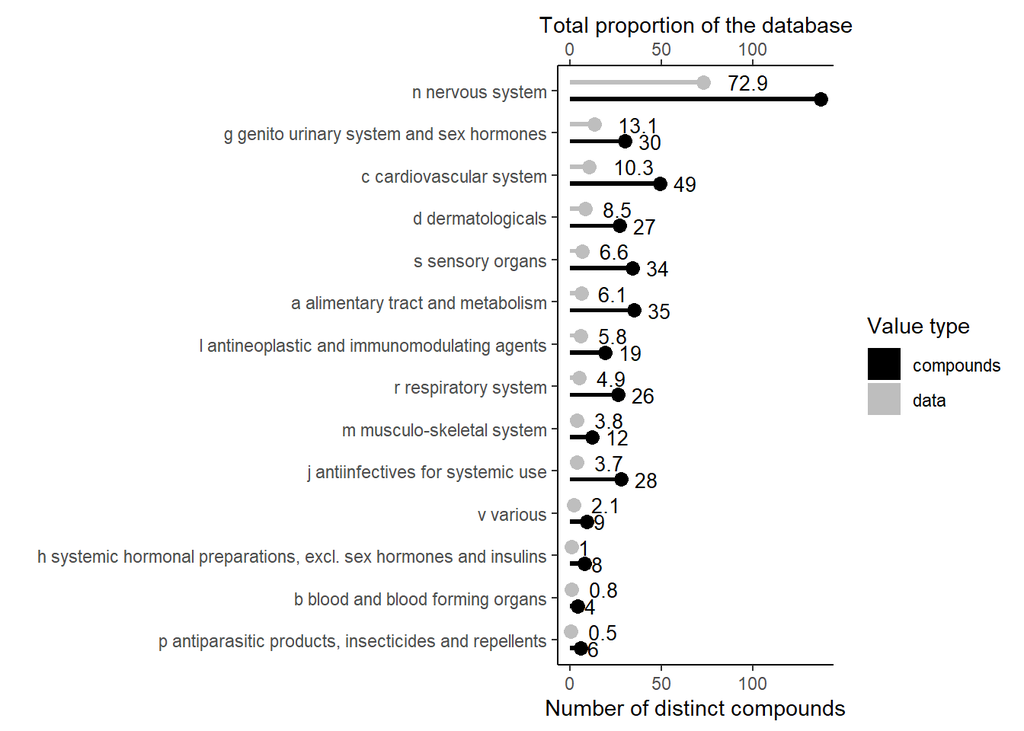

```r
measure_colour_theme <- c("black", "grey")  # Making colour theme to apply to plot

# Making a list of act names in the order that we want them in the plot
level_1_order <- ATC_L1_summary %>%
    dplyr::filter(measure == "data") %>%
    dplyr::arrange(value) %>%
    dplyr::pull(compound_atc_level_1)

# Making the plot
atc_level_1_fig <- ATC_L1_summary %>%
    dplyr::mutate(compound_atc_level_1 = factor(compound_atc_level_1, levels = level_1_order)) %>%
    ggplot(aes(x = compound_atc_level_1, y = value, colour = measure, fill = measure,
        group = measure)) + geom_col(position = position_dodge(width = 0.8), width = 0.2,
    colour = NA) + geom_point(position = position_dodge(width = 0.8), size = 3) +
    geom_text(aes(label = value), hjust = -0.6, size = 3.5, color = "black", position = position_dodge(width = 0.8)) +
    scale_colour_manual(values = measure_colour_theme, name = "Value type") + scale_fill_manual(values = measure_colour_theme,
    name = "Value type") + coord_flip() + scale_y_continuous(name = "Number of distinct compounds",
    sec.axis = sec_axis(~., name = "Total proportion of the database")  # Adjust scaling if needed
) +
    theme_classic() + labs(x = "", y = "Number of distict species in the database") +
    theme()

atc_level_1_fig
```

```r
# setwd(figures_path) ggsave('comp_atc_level_1_fig.pdf', plot =
# atc_level_1_fig, width = 10, height = 10)
```

#### 10.7.2.3 ATC level 3

Let’s seem how many classes there are at the Anatomical Therapeutic Chemical (ATC) level 3

There are 131 distinct classes, I am creating a table with the top 15.

```r
n_compound_atc <- EIPAAB_database %>%
  dplyr::filter(compound_atc_boolean == "Yes") %>%
  dplyr::distinct(compound_name) %>%
  nrow(.)

compound_ATC_L3_summary <- EIPAAB_database %>%
  dplyr::group_by(compound_name) %>%
  dplyr::sample_n(1) %>% # sampling one row per article per species (i.e. ignoring multiple rows per article for compounds)
  dplyr::ungroup() %>%
  dplyr::filter(compound_atc_boolean == "Yes") %>%
  dplyr::group_by(compound_atc_level_3) %>%
  dplyr::reframe(n = n()) %>%
  dplyr::mutate(compound_atc_level_3 = str_trim(compound_atc_level_3)) %>%
  tidyr::separate_rows(compound_atc_level_3, sep = ";") %>% # each spp has multiple habitats the string needs splitting
  dplyr::group_by(compound_atc_level_3) %>%
  dplyr::reframe(n = sum(n),
                 percent = round(n/n_compound_atc*100,1),
                 measure = "compounds") %>% # now a sum for each habitat
  arrange(desc(n))

compound_ATC_L3_summary %>%
  dplyr::select(-measure) %>%
  dplyr::slice(1:15) %>% # only the first 15
  gt()
```

| compound_atc_level_3 | n | percent |
| --- | --- | --- |
| n06a antidepressants | 27 | 8.9 |
| n03a antiepileptics | 18 | 5.9 |
| n05a antipsychotics | 14 | 4.6 |
| a01a stomatological preparations | 12 | 3.9 |
| n05b anxiolytics | 11 | 3.6 |
| n05c hypnotics and sedatives | 11 | 3.6 |
| n06b psychostimulants, agents used for adhd and nootropics | 11 | 3.6 |
| r06a antihistamines for systemic use | 11 | 3.6 |
| c07a beta blocking agents | 9 | 3.0 |
| d04a antipruritics, incl. antihistamines, anesthetics, etc. | 9 | 3.0 |
| s01e antiglaucoma preparations and miotics | 9 | 3.0 |
| c05a agents for treatment of hemorrhoids and anal fissures for topical use | 8 | 2.6 |
| g03c estrogens | 8 | 2.6 |
| n01a anesthetics, general | 8 | 2.6 |
| c10a lipid modifying agents, plain | 7 | 2.3 |

Now we will make a similar data file to look at the overall use in the database at each ATC level 3.

Below I make a table with the top 15

```r
n_data_atc <- EIPAAB_database %>%
  dplyr::filter(compound_atc_boolean == "Yes") %>%
  nrow(.)

compound_ATC_L3_data_summary <- EIPAAB_database %>%
  dplyr::filter(compound_atc_boolean == "Yes") %>%
  dplyr::group_by(compound_atc_level_3) %>%
  dplyr::reframe(n = n()) %>%
  dplyr::mutate(compound_atc_level_3 = str_trim(compound_atc_level_3)) %>%
  tidyr::separate_rows(compound_atc_level_3, sep = ";") %>% # each spp has multiple habitats the string needs splitting
  dplyr::group_by(compound_atc_level_3) %>%
  dplyr::reframe(n = sum(n),
                 percent = round(n/n_data_atc*100,1),
                 measure = "data") %>% # now a sum for each habitat
  arrange(desc(percent))

compound_ATC_L3_data_summary %>%
  dplyr::select(-measure) %>%
  dplyr::slice(1:15) %>%
  gt()
```

| compound_atc_level_3 | n | percent |
| --- | --- | --- |
| n06a antidepressants | 424 | 27.6 |
| n03a antiepileptics | 164 | 10.7 |
| n05b anxiolytics | 149 | 9.7 |
| g03c estrogens | 121 | 7.9 |
| n06b psychostimulants, agents used for adhd and nootropics | 84 | 5.5 |
| l02a hormones and related agents | 64 | 4.2 |
| d11a other dermatological preparations | 62 | 4.0 |
| n05a antipsychotics | 60 | 3.9 |
| m01a antiinflammatory and antirheumatic products, non-steroids | 50 | 3.3 |
| n02a opioids | 51 | 3.3 |
| m02a topical products for joint and muscular pain | 48 | 3.1 |
| n02b other analgesics and antipyretics | 45 | 2.9 |
| n05c hypnotics and sedatives | 40 | 2.6 |
| c07a beta blocking agents | 38 | 2.5 |
| r02a throat preparations | 35 | 2.3 |

Here we make a new column called value where we combined the count of distinct compounds and proportion of data

```r
ATC_L3_summary <- compound_ATC_L3_summary %>%
    rbind(., compound_ATC_L3_data_summary) %>%
    dplyr::mutate(value = if_else(measure == "compounds", n, percent))
```

#### 10.7.2.4 Fig 4a

This plot shows the number of different compounds in each ATC classification as well as the total proportion of data it makes up. This is done for only the 15 most commonly used groups.

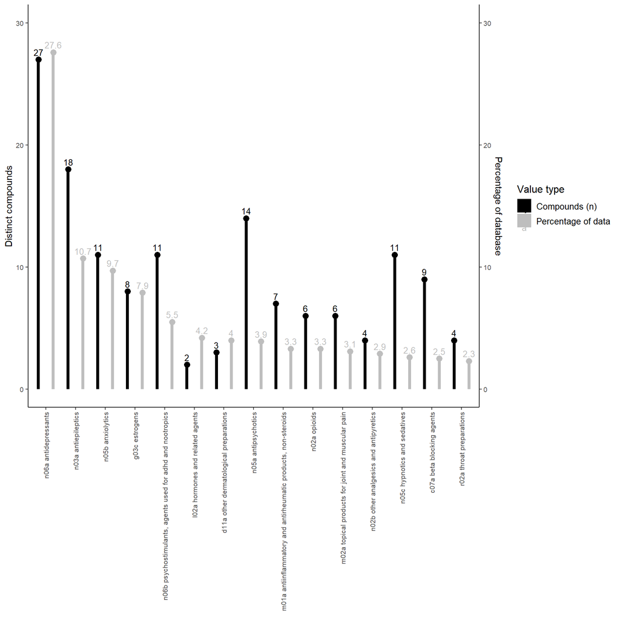

```r
measure_colour_theme <- c("black", "grey") # Making colour theme to apply to plot

# Making a list of act names in the order that we want them in the plot
level_3_order_top_15 <- ATC_L3_summary %>%
  dplyr::filter(measure == "data") %>%
  dplyr::arrange(desc(value)) %>%
  dplyr::slice(1:15) %>%
  dplyr::arrange(desc(value)) %>%
  dplyr::pull(compound_atc_level_3)

# Making the plot
atc_level_3_fig <- ATC_L3_summary %>%
  dplyr::filter(compound_atc_level_3 %in% level_3_order_top_15) %>%
  dplyr::mutate(compound_atc_level_3 = factor(compound_atc_level_3, levels = level_3_order_top_15)) %>%
  ggplot(aes(x=compound_atc_level_3, y=value, fill = measure, colour = measure,
             group = measure)) +
  geom_col(position = position_dodge(width = 1), width = 0.2, colour = NA,) +
  geom_point(position = position_dodge(width = 1), size = 3) +
  geom_text(aes(label = value), vjust=-0.6, size=3.5, position =  position_dodge(width = 1)) +
  scale_colour_manual(values = measure_colour_theme, name = "Value type",
                      labels = c("Compounds (n)", "Percentage of data")) +
  scale_fill_manual(values = measure_colour_theme, name = "Value type",
                      labels = c("Compounds (n)", "Percentage of data")) +
  scale_y_continuous(
    name = "Distinct compounds",
    limits = c(0, 30),                   # Set the range of y-axis
    breaks = c(0, 10, 20, 30),           # Set the labels at 0, 10, 20, 30
    sec.axis = sec_axis(~ . , name = "Percentage of database") # Adjust scaling if needed
  ) +
  theme_classic() +
   labs(
    x = "",
    y = ""
  ) +
   theme(
    axis.text.y = element_text(size = 8),          # Change y-axis labels size
    axis.text.x = element_text(angle = 90, vjust = 0.5, hjust=1, size = 8), # Change x-axis labels orientation
    legend.title = element_text(size = 12),         # Change legend title size if needed
    legend.text = element_text(size = 10)
   )

atc_level_3_fig
```

Save the figure

```r
# setwd(figures_path) ggsave('atc_level_3_fig.pdf', plot = atc_level_3_fig,
# width = 10, height = 5)
```

### 10.7.3 Most common compounds

Overall the most common compounds are Fluoxetine, Diazepam and 17-alpha-ethinylestradiol

Below is a table of the top 15 compounds

```r
n_row <- EIPAAB_database %>%
    nrow(.)

compound_use <- EIPAAB_database %>%
    dplyr::group_by(compound_name) %>%
    dplyr::reframe(n = n()) %>%
    dplyr::mutate(prop = n/n_row) %>%
    arrange(desc(prop))

compound_use %>%
    dplyr::slice(1:15) %>%
    gt()
```

| compound_name | n | prop |
| --- | --- | --- |
| Fluoxetine | 200 | 0.11500863 |
| Diazepam | 67 | 0.03852789 |
| 17-alpha-ethinylestradiol | 63 | 0.03622772 |
| Caffeine | 45 | 0.02587694 |
| Venlafaxine | 43 | 0.02472685 |
| Citalopram | 42 | 0.02415181 |
| Sertraline | 39 | 0.02242668 |
| Carbamazepine | 38 | 0.02185164 |
| Buspirone | 30 | 0.01725129 |
| Morphine | 27 | 0.01552616 |
| Oxazepam | 26 | 0.01495112 |
| Valproate | 24 | 0.01380104 |
| 17-beta-estradiol | 23 | 0.01322599 |
| Ibuprofen | 20 | 0.01150086 |
| Nicotine | 19 | 0.01092582 |

Let’s see what the numbers are for each motivation, but let’s also maintain the overall numbers so we can add it to the figure

```r
n_row <- EIPAAB_database %>%
    nrow(.)

compound_use_motivation <- EIPAAB_database %>%
    dplyr::group_by(study_motivation, compound_name) %>%
    dplyr::summarise(n = n(), .groups = "drop") %>%
    tidyr::complete(compound_name, study_motivation, fill = list(n = 0))  # Making sure we have a complete dataframe

compound_use_motivation <- compound_use %>%
    dplyr::select(-prop) %>%
    dplyr::mutate(study_motivation = "All") %>%
    rbind(., compound_use_motivation)
```

The top 10 based on each study motivation as well as the overall total

```r
top_10_comp_all_fig <- compound_use_motivation %>%
    dplyr::filter(study_motivation == "All") %>%
    dplyr::arrange(desc(n)) %>%
    dplyr::slice(1:10) %>%
    dplyr::mutate(compound_name = fct_reorder(compound_name, n)) %>%
    ggplot(aes(x = compound_name, y = n)) + geom_col(width = 0.1, colour = NA, fill = "grey") +
    geom_point(size = 3, colour = "grey", fill = "grey") + geom_text(aes(label = n),
    hjust = -0.6, size = 3.5, color = "black") + coord_flip() + theme_classic() +
    labs(title = "All", x = "", y = "Total use in the database") + theme(plot.title = element_text(size = 11))


top_10_comp_env_fig <- compound_use_motivation %>%
    dplyr::filter(study_motivation == "Environmental") %>%
    dplyr::arrange(desc(n)) %>%
    dplyr::slice(1:10) %>%
    dplyr::mutate(compound_name = fct_reorder(compound_name, n)) %>%
    ggplot(aes(x = compound_name, y = n)) + geom_col(width = 0.1, colour = NA, fill = "#60BD6C") +
    geom_point(size = 3, colour = "#60BD6C", fill = "#60BD6C") + geom_text(aes(label = n),
    hjust = -0.6, size = 3.5, color = "black") + coord_flip() + theme_classic() +
    labs(title = "Environmental", x = "", y = "Total use in the database") + theme(plot.title = element_text(size = 11))


top_10_comp_med_fig <- compound_use_motivation %>%
    dplyr::filter(study_motivation == "Medical") %>%
    dplyr::arrange(desc(n)) %>%
    dplyr::slice(1:10) %>%
    dplyr::mutate(compound_name = fct_reorder(compound_name, n)) %>%
    ggplot(aes(x = compound_name, y = n)) + geom_col(width = 0.1, colour = NA, fill = "#D359A1") +
    geom_point(size = 3, colour = "#D359A1", fill = "#D359A1") + geom_text(aes(label = n),
    hjust = -0.6, size = 3.5, color = "black") + coord_flip() + theme_classic() +
    labs(title = "Medical", x = "", y = "Total use in the database") + theme(plot.title = element_text(size = 11))

top_10_comp_base_fig <- compound_use_motivation %>%
    dplyr::filter(study_motivation == "Basic research") %>%
    dplyr::arrange(desc(n)) %>%
    dplyr::slice(1:10) %>%
    dplyr::mutate(compound_name = fct_reorder(compound_name, n)) %>%
    ggplot(aes(x = compound_name, y = n)) + geom_col(width = 0.1, colour = NA, fill = "#3C82C4") +
    geom_point(size = 3, colour = "#3C82C4", fill = "#3C82C4") + geom_text(aes(label = n),
    hjust = -0.6, size = 3.5, color = "black") + coord_flip() + theme_classic() +
    labs(title = "Basic Research", x = "", y = "Total use in the database") + theme(plot.title = element_text(size = 11))
```

#### 10.7.3.1 Fig 4b

Here are the resulting figures

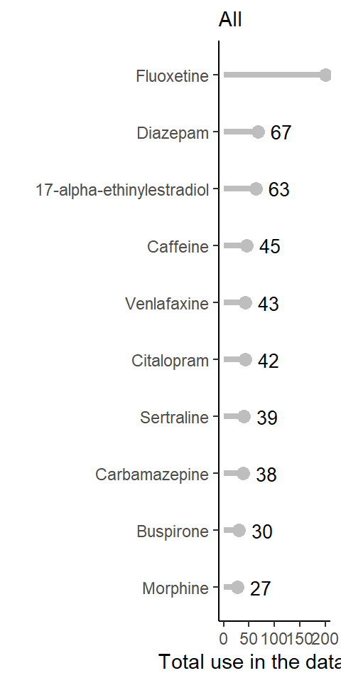

```r
top_10_comp_all_fig
```

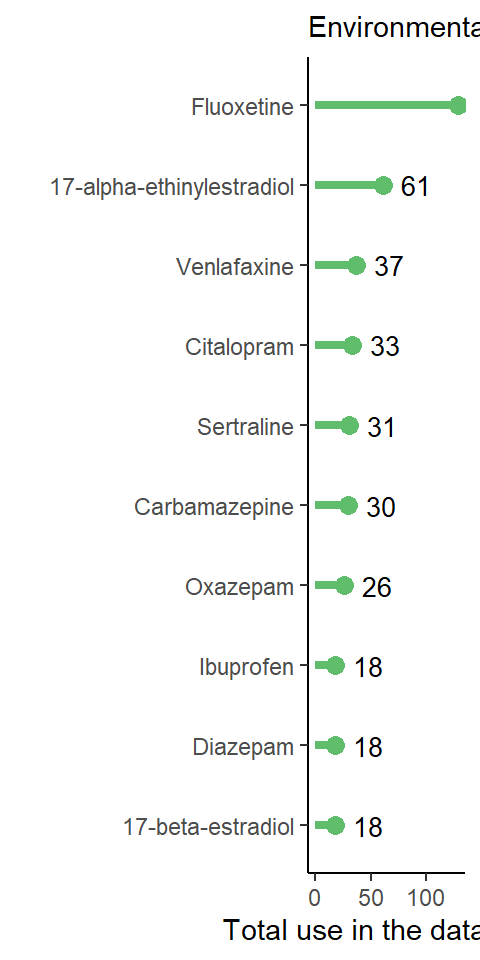

```r
top_10_comp_env_fig
```

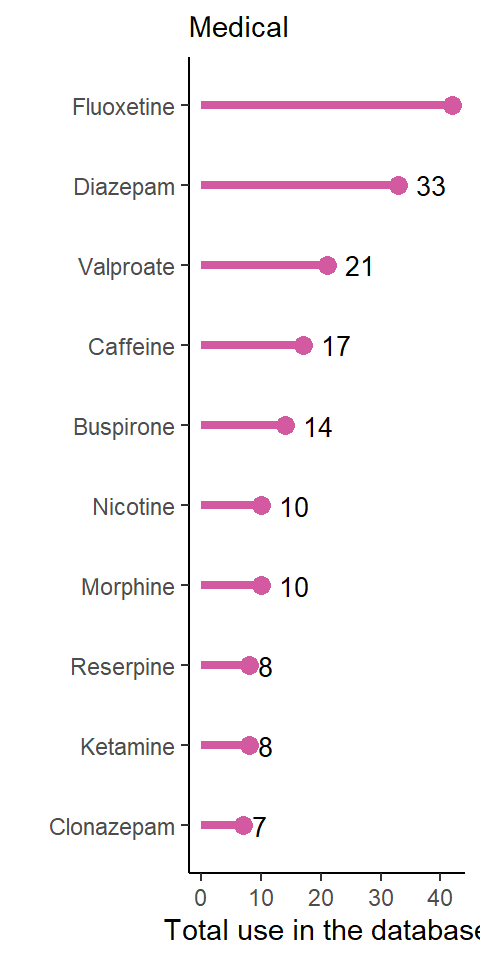

```r
top_10_comp_med_fig
```

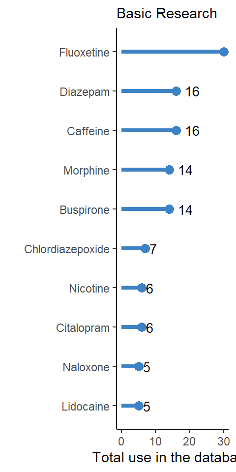

```r
top_10_comp_base_fig
```

Saving as PDFs

```r
# setwd(figures_path) ggsave('comp_top_10_comp_all_fig.pdf', plot =
# top_10_comp_all_fig, width = 5, height = 10)
# ggsave('comp_top_10_comp_env_fig.pdf', plot = top_10_comp_env_fig, width = 5,
# height = 10) ggsave('comp_top_10_comp_med_fig.pdf', plot =
# top_10_comp_med_fig, width = 5, height = 10)
# ggsave('comp_top_10_comp_base_fig.pdf', plot = top_10_comp_base_fig, width =
# 5, height = 10)
```

### 10.7.4 Mixtures

It was recorded whether the animals were also exposed to compound mixtures

```r
EIPAAB_database %>%
    dplyr::group_by(article_id) %>%
    dplyr::sample_n(1) %>%
    dplyr::ungroup() %>%
    dplyr::reframe(mixture_yes = sum(compond_mixture == "Yes", na.rm = TRUE), mixture_no = sum(compond_mixture ==
        "No", na.rm = TRUE), mixture_percent = (mixture_yes/mixture_no) * 100) %>%
    gt()
```

| mixture_yes | mixture_no | mixture_percent |
| --- | --- | --- |
| 165 | 736 | 22.41848 |

Medical articles have a much higher use of mixtures

```r
EIPAAB_database %>%
    dplyr::group_by(article_id) %>%
    dplyr::sample_n(1) %>%
    dplyr::ungroup() %>%
    dplyr::group_by(study_motivation) %>%
    dplyr::reframe(mixture_yes = sum(compond_mixture == "Yes", na.rm = TRUE), mixture_no = sum(compond_mixture ==
        "No", na.rm = TRUE), mixture_percent = round((mixture_yes/mixture_no) * 100,
        1)) %>%
    gt()
```

| study_motivation | mixture_yes | mixture_no | mixture_percent |
| --- | --- | --- | --- |
| Environmental | 57 | 453 | 12.6 |
| Medical | 76 | 157 | 48.4 |
| Basic research | 32 | 126 | 25.4 |

### 10.7.5 Exposure route

Data on the method of exposure was also extracted

```r
nrow <- EIPAAB_database %>%
    nrow(.)

EIPAAB_database %>%
    dplyr::group_by(compound_expose_route) %>%
    dplyr::reframe(n = n(), percent = round((n/nrow) * 100, 1)) %>%
    gt()
```

| compound_expose_route | n | percent |
| --- | --- | --- |
| Other exposure route | 223 | 12.8 |
| Waterborne only | 1500 | 86.3 |
| Waterborne plus any other route | 16 | 0.9 |

### 10.7.6 Exposure length

The database has both the minimum and maximum duration of exposure prior to behavioural measure (compound_min_duration_exposure and compound_max_duration_exposure). Here we will focus on the maximum duration

These are the different categories of exposure length

```r
EIPAAB_database %>%
    dplyr::distinct(compound_max_duration_exposure) %>%
    gt()
```

| compound_max_duration_exposure |
| --- |
| Less than 6 hours |
| 1 to 3 months |
| 3 to 8 days |
| 22 to 29 days |
| Multigenerational |
| 6 to 24 hours |
| 1 to 3 days |
| 8 to 15 days |
| Not stated |
| 15 to 22 days |
| Transgenerational |
| 3 to 6 months |
| Lifetime |

Some articles did not report the exposure duration at all, or in sufficient detail to extract.

In total this occurred in 108 cases

```r
EIPAAB_database %>%
    dplyr::filter(compound_min_duration_exposure == "Not stated" | compound_max_duration_exposure ==
        "Not stated") %>%
    nrow(.)
```

```
## [1] 108
```

Summary table

```r
exposure_duration_order <- c("Less than 6 hours", "6 to 24 hours", "1 to 3 days",
    "3 to 8 days", "8 to 15 days", "15 to 22 days", "22 to 29 days", "1 to 3 months",
    "3 to 6 months", "Lifetime", "Transgenerational", "Multigenerational")

nrow <- EIPAAB_database %>%
    dplyr::filter(compound_max_duration_exposure != "Not stated") %>%
    nrow(.)

exposure_duration_summary <- EIPAAB_database %>%
    dplyr::filter(compound_max_duration_exposure != "Not stated") %>%
    dplyr::group_by(compound_max_duration_exposure) %>%
    dplyr::reframe(n = n(), percent = round((n/nrow) * 100, 1)) %>%
    dplyr::mutate(compound_max_duration_exposure = factor(compound_max_duration_exposure,
        levels = exposure_duration_order)) %>%
    dplyr::arrange(compound_max_duration_exposure) %>%
    dplyr::mutate(study_motivation = "All")

exposure_duration_summary %>%
    gt()
```

| compound_max_duration_exposure | n | percent | study_motivation |
| --- | --- | --- | --- |
| Less than 6 hours | 679 | 41.3 | All |
| 6 to 24 hours | 129 | 7.9 | All |
| 1 to 3 days | 106 | 6.5 | All |
| 3 to 8 days | 317 | 19.3 | All |
| 8 to 15 days | 101 | 6.1 | All |
| 15 to 22 days | 113 | 6.9 | All |
| 22 to 29 days | 59 | 3.6 | All |
| 1 to 3 months | 83 | 5.1 | All |
| 3 to 6 months | 23 | 1.4 | All |
| Lifetime | 9 | 0.5 | All |
| Transgenerational | 15 | 0.9 | All |
| Multigenerational | 9 | 0.5 | All |

By motivation

```r
exposure_duration_order <- c("Less than 6 hours", "6 to 24 hours", "1 to 3 days",
    "3 to 8 days", "8 to 15 days", "15 to 22 days", "22 to 29 days", "1 to 3 months",
    "3 to 6 months", "Lifetime", "Transgenerational", "Multigenerational")


exposure_duration_motivation_summary <- EIPAAB_database %>%
    dplyr::filter(compound_max_duration_exposure != "Not stated") %>%
    dplyr::group_by(compound_max_duration_exposure, study_motivation) %>%
    dplyr::summarise(n = n(), .groups = "drop") %>%
    tidyr::complete(compound_max_duration_exposure, study_motivation, fill = list(n = 0)) %>%
    dplyr::group_by(study_motivation) %>%
    dplyr::mutate(total_motivation = sum(n)) %>%
    dplyr::ungroup() %>%
    dplyr::mutate(percent = round((n/total_motivation) * 100, 1)) %>%
    dplyr::select(-total_motivation)

exp_duration_motivation_summary <- exposure_duration_motivation_summary %>%
    rbind(exposure_duration_summary) %>%
    dplyr::mutate(compound_max_duration_exposure = factor(compound_max_duration_exposure,
        levels = rev(exposure_duration_order))) %>%
    dplyr::arrange(desc(compound_max_duration_exposure))
```

Making plots for each study motivation

```r
exp_duration_all_fig <- exp_duration_motivation_summary %>%
    dplyr::filter(study_motivation == "All") %>%
    ggplot(aes(x = compound_max_duration_exposure, y = percent)) + geom_col(width = 0.1,
    colour = NA, fill = "grey") + geom_point(size = 3, colour = "grey", fill = "grey") +
    geom_text(aes(label = percent), vjust = -0.6, size = 3.5, color = "black") +
    theme_classic() + coord_flip() + labs(title = "All", x = "", y = "Total percentage") +
    theme(plot.title = element_text(size = 11))


exp_duration_env_fig <- exp_duration_motivation_summary %>%
    dplyr::filter(study_motivation == "Environmental") %>%
    ggplot(aes(x = compound_max_duration_exposure, y = percent)) + geom_col(width = 0.1,
    colour = NA, fill = "#60BD6C") + geom_point(size = 3, colour = "#60BD6C", fill = "#60BD6C") +
    geom_text(aes(label = percent), vjust = -0.6, size = 3.5, color = "black") +
    theme_classic() + coord_flip() + labs(title = "Environmental", x = "", y = "Total percentage") +
    theme(plot.title = element_text(size = 11))

exp_duration_med_fig <- exp_duration_motivation_summary %>%
    dplyr::filter(study_motivation == "Medical") %>%
    ggplot(aes(x = compound_max_duration_exposure, y = percent)) + geom_col(width = 0.1,
    colour = NA, fill = "#D359A1") + geom_point(size = 3, colour = "#D359A1", fill = "#D359A1") +
    geom_text(aes(label = percent), vjust = -0.6, size = 3.5, color = "black") +
    theme_classic() + coord_flip() + labs(title = "Medical", x = "", y = "Total percentage") +
    theme(plot.title = element_text(size = 11))


exp_duration_base_fig <- exp_duration_motivation_summary %>%
    dplyr::filter(study_motivation == "Basic research") %>%
    ggplot(aes(x = compound_max_duration_exposure, y = percent)) + geom_col(width = 0.1,
    colour = NA, fill = "#3C82C4") + geom_point(size = 3, colour = "#3C82C4", fill = "#3C82C4") +
    geom_text(aes(label = percent), vjust = -0.6, size = 3.5, color = "black") +
    theme_classic() + coord_flip() + labs(title = "Basic research", x = "", y = "Total percentage") +
    theme(plot.title = element_text(size = 11))
```